# 1 Module 1 - Encapsulation

## 1.1 Description

One of the major motivation for good design is to keep control of the complexity of a system. An idea that is paramount to simplifying the design of software is encapsulation. Ideally, classes serve to support functionality, but also to isolate distinct computations. This module will cover the most important concepts and techniques necessary to design well-encapsulated classes.

## 1.2 Learning Objectives

After this module you should:

- Be able to explain the concepts of *encapsulation* and *information hiding*;
- Evaluate the quality of encapsulation realized by a single class;
- Know some of the programming language mechanisms and idioms that support encapsulation, and how to apply them;
- Understand the importance of *immutability* in software design and how to make Java classes immutable.
- Know about the concept of Design by Contract and how to apply it to Java programs using the `assert` statement;
- Know about *code style*, be able to explain how it contributes to code quality, and be able to apply a code-style checker and interpret its results;
- Be able to create and interpret Object Diagrams.

## 1.3 Notes

### 1.3.1 General Concepts and Definitions

The idea of **encapsulation** is to "to enclose in or as if in a capsule" [[Merriam-Webster](https://www.merriam-webster.com/dictionary/Encapsulation)]. For example, you can think of a nut, which is encapsulated in its shell. The shell, or capsule, serves as protection. In software design we encapsulate both data and computation both to protect them from corruption, and to simplify the design. Encapsulation in software design is related to the principle of **information hiding**, which has been around since the early 1970s. According to [Vogel et al.](http://link.springer.com/book/10.1007/978-3-642-19736-9) "The principle generally states that you only show a client that part of the total information that is really necessary for the client's task and you hide all remaining information."

One of the first problems we will tackle in this module is to design an abstraction that can conveniently represent a single playing card. In a standard deck of cards there are 52 distinct cards and any given card can be completely defined by its *suit* (Hearts, Spades, Diamonds, Clubs) and its *rank* (Ace, 2, 3,...,10, Jack, Queen, King). In a program we can represent a playing card in many different ways. For example, using a single integer between 0 and 51 where the value of the integer somehow represents the card. Or, we could represent a card using a combination of 6 boolean values (insane but technically possible). Here to apply the principle of information hiding, we would organize our program structure so as to *hide* the decision of how exactly we represent a card in the program.

The fact that we can represent a card in many different ways is also a good illustration of the concept of a **design space**. The design space is an imaginary multi-dimensional vector space where every dimension corresponds to a design quality attribute (like understandability, reusability, ease of implementation, etc.). Within such a design space, each specific design decision corresponds to a point. The figure below illustrates the idea. Each decision is likely to be good in some dimension, but less good in others, something we call a **design trade-off**. Two sub-spaces of the design space that are useful to consider are the space of *possible solutions*, and the space of *acceptable solutions*. Note that the theoretically optimal solution, which best satisfies all dimensions at the same time, is unlikely to be possible. All this to say that design is a decision process for which there is rarely a single "right answer", only answers that are better or worse in some dimensions (including some answers that are pretty bad in most dimensions). In practice, the challenge of choosing a point in the design space is compounded by the fact that assessing the quality of a solution, even within a single dimension, is a very approximate process, and that we don't usually know what the optimal solution is.

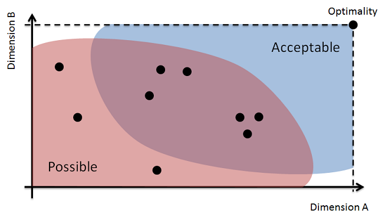

Exploring the design space

### 1.3.2 Designing Basic Abstractions

One of the main activities of software design is to *define abstractions* using programming languages mechanisms. Ideally the abstractions we define will:

- clearly map to concepts in the problem domain (to facilitate program understanding)
- be well-encapsulated (see above)

One of the main mechanisms we use to define abstractions in type-based object-oriented languages is, not surprisingly, the *type*.

Consider the following bad example:

```java
int card = 0; // The ace of clubs
```

Here our decision is to use the integer primitive type as the abstraction to represent a playing card. Notice how this achieves neither of the two desirable properties above. The `int` type maps to the concept of integers (a type of number), not that of a playing card. You could rename the variable to `socialInsuranceNumber` while it still holds a value for a card, and achieve maximum confusion. It is also not well-encapsulated because you could assign the value 53 to the variable and corrupt it.

For this reason it's generally a bad idea to try to shoehorn domain concepts into default types like integer or string. The `int` type should only be used to hold actual integers (and very similar concepts, such as currency), and similarly with strings.

In other cases we want to use our own type (or one defined by a library):

```java
class Card {}
```

If we started to design this type, we would quickly realize that our program also needs to manipulate two other types of values: *suits* and *ranks*. These types of values are a bit different because they are more like labels for domain objects than actual objects. What makes them feel like labels are that there are a finite number of them for a particular type of values (e.g., 4 for suits), and it appears to be useless to have two or more instances representing a given suit (e.g., clubs). In fact values of these types would be used more or less as *constants* in a program.

```java
private static int CLUBS = 0;
private static int HEARTS = 1;
...
```

There is a specific mechanism for representing these kinds of values called the [Enumerated Type](https://docs.oracle.com/javase/tutorial/java/javaOO/enum.html), or "enum types" for short. It's better to avoid the single colloquial term "enum" because it's not clear whether it refers to an enumerated type or a value of this type. Enumerated types are a truly powerful feature for software design, and I will use them extensively throughout this course. The one slight weakness of enumerated types in Java is that in addition to the enumerated values:

```java
public enum Suit
{
    CLUBS, DIAMONDS, SPADES, HEARTS
}
```

a variable of an enumerated type can also take the value `null`:

```java
Suit suit = Suit.CLUBS;
suit = null;
```

This is not a feature, but rather a consequence of how enumerated types are implemented in Java (as reference types). A good programming practice is to never consider the `null` value to be a legal value when using enumerated types.

### 1.3.3 Basic Class Encapsulation Guidelines

The following guidelines, explained in class, will help you define well-encapsulated classes:

- Make all fields private. Later in the course I will describe how in some specific cases it may make sense to define them as `protected`. Extremely rarely is it desirable to leave them `public` or `packaged-scope` (default).
- Do not automatically supply a class with a "getter" (a.k.a. "accessor") and "setter" (a.k.a. "mutator") method for every field.
- Try to avoid defining methods that both change ("mutate") the state of an object and return ("access") a value.
- Define your instance variables as `final` whenever possible. In Java the `final` designation for an instance or class variable indicates that it is not possible to re-assign (change) the value of the variable after it is initialized. However, remember that in Java values for references types are the references themselves, not the object they reference. This means that if the declared type for a final field is a reference type, although it will not be possible to assign the field to a different object, it will always be possible to change that object. More on this topic in Module 3.
- Make your classes **immutable** whenever possible. An *immutable* class generates instances whose state it is impossible to change. For example, instances of the class `String` cannot be modified, so they are immutable.
- Ensure your accessor methods do not return a reference to a mutable instance variable. In general, *it should never be possible to modify the internal state of an object without going through this object's instance methods*. If you need other objects to access instance variables that are held in mutable objects, return a copy of the object instead (see below). Note that values primitive types are copied by default.

### 1.3.4 Scope

A bit of important terminology about various variable *scopes* that impact encapsulation. A scope for a variable refers to the subset of the program where that variable is visible and can be accessed. At this point in the course it's useful to distinguish between three different scopes:

- **Global Scope**: Class variables (a.k.a. static fields) denoted as `public` can be accessed by any other part of the program, and are said to be *global*. Similarly, instance variables (a.k.a. non-static fields) denoted as `public` can be accessed by any part of the program that transitively has a reference to the corresponding instance. These are also considered to be in the global scope. Ideally very few elements should be in the global scope, if any.
- **Object Scope**: Instance variables (a.k.a. non-static fields) denoted as `private` can (only) be accessed by methods that take the same instance as implicit parameters (i.e., methods on the same object). These are considered to be in the object scope. The "object scope" is a useful concept for design, especially when considering the problem of escaping references (see below). However, the concept of an object scope is not supported by the Java language, which has a strictly static view of scopes. In Java, instances variables ("fields") are placed in the *class scope*, which approximates the idea of the object scope, but provides additional flexibility when implementing things like copy constructors (or the `equals` method, something we will see later). Consider the code below:

```java
public class Card
{
   private Rank aRank;
   private Suit aSuit;

   public Card( Card pCard )
   {
      aRank = pCard.aRank;
      aCard = pCard.aSuit;
   }
   ...
```

Here the code in the constructor can see the private `aRank` and `aSuit` fields of a *different* `Card` object, because the references happen between members of the same class. This situation can be a bit confusing at first, but it's good to remember that it's somewhat of a special case. For all the code except the methods of `Card`, the object scope and the class scope will overlap.

- **Local Scope**: Local variables are only accessible within their immediately encompassing block scope (in most cases that is the innermost set of curly braces encompassing the variable definition. Locals variables are obviously restricted to their local scope, but also formal method parameters, exception variables, etc.
- **Other Scopes**: There are other scopes to consider for more advanced design problems, including package scope, class-hierarchy scope, scopes for closures, etc. These will be introduced as necessary. For Module 1 only the three basic scopes are relevant.

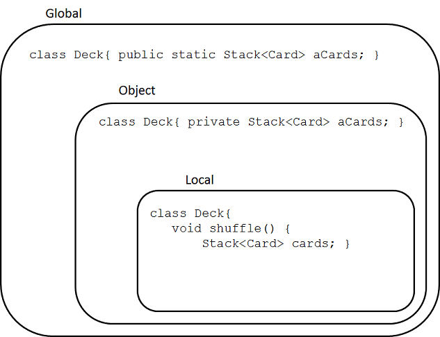

One of the ways we can achieve good encapsulation is to always define variables in the tightest scope possible. Unfortunately, in Java values can **escape their scope**, and it's our job as a good programmer to make sure they can't. Here's are the four typical routes of escape in Java, illustrated with the code below for object scopes.

- **There is no door:** If a variable is in the global scope, it escapes by default because it is not contained. This is somewhat of a degenerate case.
- **The front door is open:** If an accessor method returns a reference to an instance variable in the object scope, the reference escapes the object scope. One solution here is to copy the object before returning it.
- **The door was not closed:** If an instance variable is assigned a value obtained from a parameter, the caller of the method retains a reference to the object, which means the value is not properly captured by the object scope. One solution here is to copy the object before assigning it.
- **The back door is open:** If a reference to an instance variable is stored within an object that can be referenced from outside the object scope, then the reference escapes the object scope. One solution here is to copy the object before storing it in the provided data structure, but often this kind of convoluted design can be improved to avoid the problem in the first place.

```java
public class Deck
{
   /* There is no door */
   public Stack<Card> aCards = new Stack<>();

   /* The front door is open */
   public Stack<Card> getCards()
   { return aCards; }

   /* The door was not closed */
   public void setStack(Stack<Card> pCards)
   { aCards = pCards; }

   /* The back door is open */
   public void applyAll( List<Stack<Card>> pTaskList )
   { pTaskList.add(aCards); }
}
```

### 1.3.5 Design by Contract

The idea of [Design by Contract](https://en.wikipedia.org/wiki/Design_by_contract) is to follow a principled approach to the specification of interfaces. Although in practice, method signatures already specify much of what is needed, they also leave a lot of room for ambiguity.

A typical case where Design by Contract is useful is to specify whether `null` is a legal input or not. Consider the following constructor for a `Card` class:

```java
public class Card
{
   public Card(Rank pRank, Suit pSuit)
   {
      ...
```

Is it legal to pass in a `null` value for `pRank` and/or `pSuit`? Maybe, maybe not. A helpful programmer could put this in the Javadocs, which is better than nothing. Design by Contract goes further and provides a formal framework for reasoning about this kind of interface information. There's a lot to say about Design by Contract. Here I only summarize what I use in the course.

The idea of Design by Contract is for method signatures (and complementary meta-data) to provide a sort of "contract" between the "client" (the caller method) and the "server" (the method being called). This contract takes the form of a set of **preconditions** and a set of **postconditions**. Given these, the contract is basically that *the method can only be expected to conform to the postconditions if the caller conforms to the preconditions*. If a client calls a method without respecting the preconditions, the behavior of the method is **unspecified**. In practice Design by Contract is a great way to force us to think about all possible ways to use a method.

In this course I adopt a lightweight version of Design by Contract where preconditions are specified using Java statements in the Javadoc using the `@pre` tag and, more rarely, postconditions are specified using the tag `@post`.

```java
   /**
    * ...
    * @pre pRank != null && pSuit != null
    */
   public Card(Rank pRank, Suit pSuit)
   {
      ...
```

It is possible to make pre- and postconditions (and any other predicate) *checkable* in Java using the `assert` statement:

```java
assert pRank != null && pSuit != null;
```

The `assert` statement evaluates the predicate in the statement and raises an `AssertionError` if the predicate evaluates to false. Unfortunately assertion checking is disabled by default in Java, so to use this properly you must add `-ea` (enable assertions) as a VM parameter when running Java programs.

Correctly implemented, Design by Contract helps prevent the annoying idiom of [defensive programming](https://en.wikipedia.org/wiki/Defensive_programming) where corner cases (such as null values) are checked for everywhere in the code. Additionally, the technique supports rapid *blame assignment* while debugging: If a precondition check fails, the client (caller method) is to blame. If a postcondition check fails, the actual method being called is to blame.

More generally, `assert` statements are a simple yet very powerful tool to increase code quality and I encourage you to use it everywhere, not just for pre- and postconditions. Whenever an assertion check fails, you know exactly where the problem is, and thus can save hours of debugging time.

```java
   /**
    * ...
    * @pre pRank != null && pSuit != null
    */
   public Card(Rank pRank, Suit pSuit)
   {
      if( pRank != null || pSuit != null ) throw new IllegalArgumentException()
      ...
```

### 1.3.6 Exposing Encapsulated Information

In a great majority of cases the objects of the classes we design will need to expose part of the information they encapsulate to other objects. How can we do this without breaking encapsulation, and in particular the cardinal rule that *it should never be possible to modify the internal state of an object without going through this object's instance methods*.

If the internal objects that need to be exposed are *immutable*, then there's no issue. For example, a `Card` object returns its rank:

```java
public class Card
{
   private Rank aRank = ...;

   public Rank getRank()
   {
      return aRank;
   }
   ...
```

but the value returned is of the enumerated type `Rank`, which is immutable, so even if the reference to `aRank` is allowed to escape the object scope, whatever other parts of the program get a hold of it can't do anything to the `Rank` object that is referenced, so, it's all good.

But what if the object that is referenced is *mutable*, as in the case of the stack encapsulated by a `Deck` class?

```java
public class Deck
{
   private final Stack<Card> aCards = new Stack<>();
```

If *it is really necessary* to provide information about the stack to other objects, we don't want to do this by returning a reference to the mutable stack. Several options are possible:

- To add methods to the `Deck` class that allow querying the state of the deck in a safe way. For example, by adding methods like `isEmpty()`, `size()`, `elementAt()`, etc. This strategy will be covered in more details in Module 2.
- To return an immutable wrapper for the collection using library methods such as `java.util.Collections.unmodifiableList(...)`. This strategy will be covered in more details in Module 5.
- To return a copy of the collection.

[Copying objects](https://en.wikipedia.org/wiki/Object_copying) is one way to help design well-encapsulated classes, but it can be a complex topic. There are different ways to copy objects in Java, each with their strengths and weaknesses:

- To use the idiom of **copy constructors**;
- To use Java's special-purpose *cloning* mechanism;
- To use features such as serialization or reflection.

Here we focus on copy constructors. The other strategies require more advanced material and their coverage is deferred to later modules.

A copy constructor is simply a constructor that takes in a parameter of the same type as the class whose objects should be copied, and copies the information from the argument object to the invoked object. For example for a `Card`:

```java
public class Card
{
   private Rank aRank;
   private Suit aSuit;

   /** Copy constructor */
   public Card( Card pCard )
   {
      aRank = pCard.aRank;
      aSuit = pCard.aSuit;
   }
}
```

It's good to know that many Java collection classes support a kind of copy constructor, for example [ArrayList](http://docs.oracle.com/javase/8/docs/api/java/util/ArrayList.html#ArrayList-java.util.Collection-);

Copying collections is a tricky topic because it requires various design decisions about the *depth* of the copy. Here it is assumed that the concepts of *shallow* vs. *deep* copying were adequately covered in the prerequisite courses, but the Wikipedia article on [object copying](https://en.wikipedia.org/wiki/Object_copying) provides a refresher, and we will cover this topic in more depth in Module 3.

### 1.3.7 The Unified Modeling Language

There will often be situations where we need to discuss various design problems and solutions that are too complex or inconvenient to describe using either source code or natural language. For this purpose we can use the [Unified Modeling Language](https://en.wikipedia.org/wiki/Unified_Modeling_Language), or UML. The UML consists in a modeling language roughly organized in terms of different types of *diagrams* that are a great way to illustrate different aspects of software without getting bogged down with all the details. They are also a language specialized for describing software design, a bit like musical notation is a language specialized for music. Try describing your favorite melody using only written English text: it's a similar idea with software.

Different people use UML in different ways for different reasons. For example, UML can be used to produce formal design documentation in Waterfall-type development processes. Others use UML to describe enough of the software to be able to automatically generate the code from the models. In COMP 303 I use UML simply for *communicating ideas about design*. The models we produce in this course are not expected to be formal or automatically transformable into code. I also use the smallest subset of the modeling language possible to cover the course material.

A very important thing to remember about UML diagrams, is that they are *models*. This means that they are not intended to capture every single little details of a solution. Ideally, a UML diagram should focus on illustrating a *single main idea* and only include the relevant information. In UML diagramming it is a common practice to leave the parts of a system that are not directly relevant to the point being illustrated.

In this course I will do all my diagramming with [JetUML](http://cs.mcgill.ca/~martin/jetuml/).

### 1.3.8 Object Diagrams

Object diagrams represent an existing graph of objects, or class *instances*. In Java, whenever a `new` statement is executed, an object is created and a reference to this object is returned and passed around. It can often be useful to visually represent the resulting graph of objects and their inter-dependent references.

In an Object Diagram a rectangle represents an object instance, with its name and type indicated as `name:type`. Both name and type information are optional, but in general it's useful to have at least one of the two. By convention in UML the name of objects (as opposed to classes) are underlined in all diagrams. Objects can contain *fields*, which are just like Java fields. They can contain a primitive value or a value that is a reference to another object. References are represented as arrows to whatever they refer to.

Consider the diagram below:

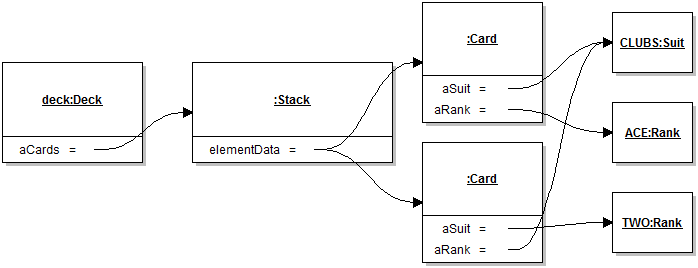

Example of Object Diagram 1

This diagram models an instance of the `Deck` class named `deck`. It would have been fine to omit this name and simply indicate `:Deck` in the rectangle, as in the case of `Stack`. This `deck` has a field `aCards` whose current value is a reference to a `Stack` object. The `Stack` object's `elementData` field references two `Card` objects. Here notice how, through modeling, we can skip over some useless details. In actual reality, in a `java.util.Stack` instance the `elementData` field refers to an array of `Object` types whose cells contain the actual data. This information is not useful here, and we link directly to the contained data. Note how the stack refers to two cards, and not 3 or 4 or 52. Another important point about Object Diagrams is that they represent a *snapshot in the execution of a program*. Here it was the point where the stack had two cards. An alternative explanation is that we didn't think it was useful to include all 52 cards to make the point that a deck is a stack of cards. The two `Card` instances, however, are modeled in full detail. Note how the values of enumerated types are distinguished by name, as it should, and that enumerated value `Suit.CLUBS` is *shared* between two cards. I will cover reference sharing in more detail in Module 3.

The second sample diagram, below, illustrates some of the modeling simplifications we can do, when appropriate.

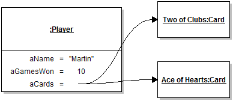

Example of Object Diagram 2

Here the field `aName`, clearly of type `String`, has the string represented as if it were a value of a primitive type. To be completely accurate down to the last detail, the value should be a reference to an instance of class `String` that has a reference to an array of `char` objects, each with one letter. That level of detail would be both superfluous and counter-productive to the goal of indicating that a `Player` object stores name information. In this second diagram, we also see that a player somehow keeps track of a number of cards, but how these are stored internally is not represented. The cards could be in an array, a list, a set, whatever. In this case it was not judged necessary to include this information. Finally, and this is maybe a bit of a stretch, the value of the `Card` instances are represented artificially by using an evocative name for the objects, instead of modeling the field values. This doesn't mean that these `Card` instances somehow don't have the `aRank` and `aSuit` fields, it just means this detail has been elided on the diagram.

## 1.4 Reading

- [Module 1 Code Samples](https://github.com/prmr/SoftwareDesignCode/tree/master/module01/ca/mcgill/cs/swdesign/m1)
- The Java Tutorial on [Enumerated Types](https://docs.oracle.com/javase/tutorial/java/javaOO/enum.html)
- Solitaire v0.1 Deck.java
- JetUML v1.0 [MultiLineString](https://github.com/prmr/JetUML/blob/v1.0/src/ca/mcgill/cs/stg/jetuml/framework/MultiLineString.java)

## 1.5 Exercises

For maximum learning effectiveness, I recommend peeking at the answers only after giving the problems an honest try.

1. Implement class `Card` as a single enumerated type. For the purpose of the Solitaire application, does this look like a superior or inferior solution to version 7 of class `Card` seen in class? Why? Try writing down your answer in specific terms using terminology seen in the book.
2. Extend the `Suit` enumerated type in `Card` to include a method `color()` that returns the color of the suit. The return type should be a new enumerated type `Color`.
3. Extend version 7 of class `Card` to support the concept of a "Joker" (a special card that is not in any suit) while keeping the class as well-encapsulated as possible.
4. Further extend your class to support any number of distinct jokers. For example, a "high" joker vs. a "low" joker, or even three jokers, etc. Again, try to keep things well-encapsulated and respectful of the class design guidelines seen in the reading.
5. Add a method `getCards()` to the `Deck` class that returns the cards in the deck without breaking encapsulation.
6. Create a new class called `MultiDeck` that contains a list of decks (some card games require multiple decks). Make the class copyable through a copy constructor. First, make a shallow copy of the decks contained. Use the debugger to confirm that the decks in a multi-deck are shared between an original multi-deck and its copies. Then, use deep copying to make copied multi-decks fully distinct object graphs. Use Design by Contract and the `assert` statement to clarify the class's interface.
7. Create a UML Object Diagram of a `MultiDeck` instance.
8. Study JetUML's [MultiLineString](https://github.com/prmr/JetUML/blob/v1.0/src/ca/mcgill/cs/stg/jetuml/framework/MultiLineString.java) class and assess the quality of its encapsulation. Is it possible to modify its state without going through its methods?

## 1.6 Answers

Answers and answer sketches to the Module 1 practice exercises.

### 1.6.1 Exercise 1

The code can be found here. With the two helper methods to get the suit and rank of the card, the answer is pretty close to the original one. To have to calculate the rank and suit from indices has lower understandability and robustness than simply storing the information directly. However, the fact that the `Card` is an immutable enumerated type gives us a number of benefits, such as the certainty that there will never be duplicate cards in a program. Personally I would still favor the version seen in class.

### 1.6.2 Exercise 2

Notice how you can define the color enumerated type as an inner type of the `Suit` type, which makes sense, because this isn't any color, but the color of a card's suit. Note also that I could have had more compact code in `getColor` by working with the enumerated value's index, but that is brittle. The current code will work even if the order of enumerated values is changed.

```
public enum Suit
{
    CLUBS, DIAMONDS, SPADES, HEARTS;

    enum Color
    {
        RED, BLACK;
    }

    public Color getColor()
    {
        if( this == CLUBS || this == SPADES )
        {
            return Color.BLACK;
        }
        else
        {
            return Color.RED;
        }
    }

    public String toString()
    {
        return name().substring(0,1) + name().substring(1, name().length()).toLowerCase();
    }
}
```

### 1.6.3 Exercise 3

**Sketch:** There are many different ways to answer this question. For a single Joker, it would make sense to have an additional boolean field `aIsJoker`. The interesting questions to solve become, what should the rank and suit of a Joker be, and what should `getRank` and `getSuit` return for a joker? Experiment with design by contract and exception handling.

### 1.6.4 Exercise 4

**Sketch:** An enumerated type seems like the right idea here to capture the type of joker. However, as I mentioned in class, it's not a good idea to consider null to be a legal value for an enumerated type, so I would recommend including an enum value to represent the case where the card is not a joker. The issues of what to do with rank and suit of jokers is the same as for Exercise 3.

### 1.6.5 Exercise 5

Assuming instances of class `Card` are immutable, it's ok to do the following, although we will see more elegant solutions in Module 2.

```
public List<Card> getCard()
{
    return new ArrayList<>(aCards);
}
```

### 1.6.6 Exercise 6

The code of a partial solution can be found here. The solution leaves out the copying part of the assignment. To implement the object copying, you will need a way to copy `Deck` and `Card` instances. One way to do this at this point is simply to define copy constructors for these two classes.

### 1.6.7 Exercise 7

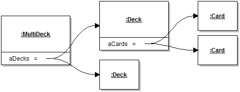

Answer to exercise 7

### 1.6.8 Exercise 8

The class is well encapsulated. The only part of the internal state returned is the inner `String`, but that is an immutable object.

# 2 Module 2 - Types and Polymorphism

## 2.1 Description

One of the main mechanisms at our disposal for designing object-oriented applications is *polymorphism*, which in the case of Java and similar languages is heavily tied to the notion of a type system. In this module I will do a brief review of the foundations of polymorphism, introduce the idea of interface programming, and present common low-level design problems that are easily solved with polymorphism.

## 2.2 Learning Objectives

After this module you should:

- Be able to explain the concept of subtype polymorphism in object-oriented programming;
- Understand and be able to use the Interface Segregation Principle;
- Be able to create and interpret UML Class Diagrams;
- Know the difference between an interface type and a class's interface;
- Be able to implement existing interfaces to provide required functionality;
- Understand the ideas of anonymous classes and function objects and be able to use them effectively;
- Know about the concept of Design Patterns;
- Be able to effectively use the *Iterator* and *Strategy* design patterns;
- Know and be able to effectively use some of the common Java utility interfaces, including `Comparable` and `Comparator`.

## 2.3 Notes

### 2.3.1 General Concepts and Definitions

In Module 1 we saw how to define well-encapsulated classes, but conveniently left out the question of how objects of these classes would interact. In Module 2 we start facing this question. Interactions between objects are mediated through *interfaces*. The term "interface" is heavily overloaded in programming: it can have different meanings depending on the context.

An **interface to a class or to an object** consists of the methods of that class (or of the object's class) that are *accessible* to another class or object. What methods are *accessible* depends on the *scoping rules* that apply to a class member. In the context of Module 2 we will keep things simple and assume that the interface to a class or object is the set of its public methods. This is not strictly true, but for Module 2 we don't need the additional distinctions. Note that I refer to the interface of a *class or object*. This simply means that the concept of interface applies to both. If we're thinking of a design solution in terms of class definitions, then the interface is that of the class. If we're thinking of a design solution in terms of a collection of instantiated objects of the class, then it's the object's interface that's relevant. We will revisit this duality in Module 3.

Consider the following program:

```java
class Game
{
   Deck aDeck;
   ...

public final class Deck
{
   private  Stack<Card> aCards = new Stack<>();
   ...
   public Deck( Deck pDeck ) {...}
   public void shuffle() {...]
   public Card draw() {...}
   public boolean isEmpty() {...}
}
```

Here the interface of class `Deck` consists of a constructor and three methods. The code in other classes can interact with objects of class `Deck` by calling these and only these methods. Here we would say that the interface of class `Deck` is *fused with the class definition*. In other words, the interface of class `Deck` is just a consequence of how we defined class `Deck`: there is no way to get the three services that correspond to the three methods of the class, without interacting with an instance of class `Deck`.

There are, however, many situations were we want to *decouple* the interface of a class from its implementation. These are situations where we want to design the system so one part of the program can depend on the availability of some services, without being tied to the exact details of how these services are implemented.

Consider the case of manipulating icons in a program:

```java
class Game
{
   Icon aIcon = ...;

   public void showIcon()
   {
      if(aIcon.getIconWidth() > 0 && aIcon.getIconHeight() > 0 )
      {
         aIcon.paintIcon(...);
      }
   }
...
```

In practice, the information representing an icon can come from different types of sources, including image files of different formats and [algorithms that compute image information on the fly](https://github.com/prmr/JetUML/blob/v1.0/src/ca/mcgill/cs/stg/jetuml/framework/ToolBar.java#L129). In this and similar cases, it is extremely useful to be able to specify an interface without tying it to a specific class. This is where **Java interfaces** come in.

In Java, interfaces provide a **specification** of the methods that it should be possible to invoke on the objects of a class. For instance the interface [Icon](http://docs.oracle.com/javase/8/docs/api/javax/swing/Icon.html) *specifies* three method signatures and documents their expected behavior.

To tie a class with an interface, we use the `implements` keyword.

```java
public class ImageIcon implements Icon
```

The `implements` keyword has two related meanings:

- It provides a formal guarantee that instances of the class type will have concrete implementations for all the methods in the interface type. This guarantee is enforced by the compiler.
- It creates a **subtype** ("is-a") relationship between the implementing class and the interface type: here we can now say than an `ImageIcon` "is-a" type of `Icon`.

The subtype relation between a concrete class and an interface is what enables the use of polymorphism. In plain language, polymorphism is the ability to have different shapes. Here, an abstractly specified `Icon` can have different concrete shapes that correspond to the different implementations of the `Icon` interface. For polymorphism to make sense in the context of a Java program it's important to remember that according to the rules of the Java type system it is possible to assign a value to a variable if the value is of the same type *or a subtype* of the type of the variable. Because the interface implementation relation defines a subtype relation, concrete classes declared to implement an interface can be assigned to variables declared to be of the interface type. Another illustration of the use of polymorphism is the use of concrete vs. abstract collection types:

```java
List<String> list = new ArrayList<>();
```

Here `List` is an interface that specifies the obvious services (add, remove, etc.), and `ArrayList` is a concrete implementation of this service. But we can just as well replace `ArrayList` with `LinkedList` and the code will still compile. Even though the details of the list implementation differ between `ArrayList` and `LinkedList`, they both provide exactly the methods required by the `List` interface, so it's permissible to swap them.

Polymorphism as supported by Java interfaces supports two very useful quality features in software design: * **Loose coupling**, because the code using a set of methods is not tied to a specific implementation of these methods. * **Extensibility**, because we can easily add new implementations of an interface (new "shapes" in the polymorphic relation).

### 2.3.2 The Comparable Interface

Common design questions related to interfaces include: *do I need a separate interface?* and *what should this interface specify?* There are no general or template answers to that question, in each case the task is to determine if interfaces can help us solve a design problem or realize a particular feature. One good illustration of both the point and usefulness of interfaces in Java is the [Comparable](http://docs.oracle.com/javase/8/docs/api/java/lang/Comparable.html) interface.

In Module 1 we solved the problem of shuffling a collection easily with the use of a library:

```java
Collections.shuffle(aCards); // Where aCards is a Stack<Card> instance
```

As you can imagine the library method `shuffle` randomly reorders the objects in the argument collection. This is an example of **code reuse** because you can reuse the library method to re-order any kind of collection. Here reuse is trivially possible because to shuffle a collection, *we don't need to know anything about the items being shuffled*.

But what if we want to reuse code to *sort* the cards in the deck? Sorting, like many classic computing problems, is supported by many existing high-quality implementations. In most realistic software development contexts it would not be acceptable to hand-craft your own sorting algorithm.

The `Collections` class conveniently supplies us with a number of sorting functions, but if we opportunistically try

```java
Collections.sort(aCards); // Where aCards is a Stack<Card> instance
```

without further thinking, we are rewarded with a moderately cryptic compilation error. This should not be surprising, though, because how exactly is a library method supposed to know how we want to sort our cards? Not only is it impossible for the designers of library methods to anticipate all the user-defined types that can be invented, but even for a given type like `Card`, different orderings are possible (e.g., by rank, then suit, or vice-versa).

The [Comparable](http://docs.oracle.com/javase/8/docs/api/java/lang/Comparable.html) interface helps solve this problem by defining a piece of behavior related specifically to the comparison of objects, in the form of a single `int compareTo(T)` method. Given the existence of this interface, the internal implementation of `Collections.sort` can now rely on it to compare the objects it should sort. You can imagine that the internal code of the `sort` implementation would have statements like:

```java
if( object1.compareTo(object2) > 0 )...
```

So here it really does not matter what the object is, *as long as it is comparable with another object*. This is a great example of how interfaces and polymorphism support loose coupling: the code of `sort` depends on the *minimum possible* set of behavior required from its argument objects.

To make it possible for us to sort a stack of cards, we therefore have to provide this *comparable* behavior and declare it through an interface implementation indication:

```java
public class Card implements Comparable<Card>
{
   @Override
   public int compareTo(Card pCard)
   {
      return pCard.getRank().ordinal() - getRank().ordinal();
   }
```

Note also that the type-checking mechanism makes it possible for the compiler to detect that a `Stack<Card>` object cannot be passed to `Collections.sort` unless the `Card` class declares to implement the `Comparable` interface. How this happens is outside the scope of this module because it requires a good understanding of the typing rules for Java generic types, something we will see later.

### 2.3.3 UML Class Diagrams

[UML Class Diagrams](http://www.ibm.com/developerworks/rational/library/content/RationalEdge/sep04/bell/index.html) represent a *static*, or *compile-time* view of a software system. They are useful to represent how *classes* are defined and related, but are a very poor vehicule for showing any kind of *run-time* property of the code. UML class diagrams are the type of UML diagrams that is the closest to the code. However, it's important to remember that the point of UML diagrams is not to be an exact translation of the code. As models, they are useful to capture the essence of one or more design decision(s) without having to include all the details.

A good reference and tutorial for [UML Class Diagrams](http://www.ibm.com/developerworks/rational/library/content/RationalEdge/sep04/bell/index.html) can be found on-line. Here is a cheat sheet of the notation I will use most commonly in the course. In the figure, all quotes are taken from [Unified Modeling Language Reference Manual, 2nd ed.](http://proquest.safaribooksonline.com/0321245628?tocview=true)

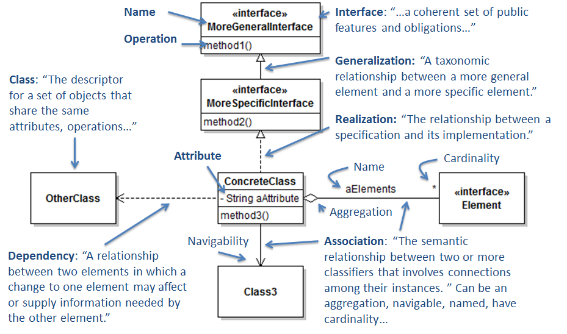

UML Class Diagram Cheat Sheet

Here is an example of a Class Diagram modeling our card game so far:

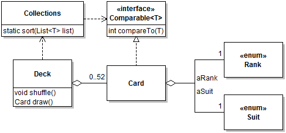

UML Class Diagram Example 1

Notice the following:

- The box representing class `Card` *does not have fields for* `aRank` and `Suit` because these are represented as aggregations to `Rank` and `Suit` enum types, respectively. *It is a modeling error* to have *both* a field *and* an aggregation representing a single value. Choose one.
- The methods of `Card` are not represented, as they are just the constructor and accessors, hardly insightful information.
- In UML, *there is no way* to indicate that a class *does not have* a certain method. So here if you want to convey the information that `Card` does not have setters for the two fields, you would have to include this using a note.
- Representing generic types is a bit problematic, because in some cases it makes more sense to represent the type parameter `Comparable<T>` and in some other cases it makes more sense to represent the type instance `Comparable<Card>`. In this sample diagram I went with the type parameter because I wanted to show how `Collections` depends on `Comparable` in general.
- All UML tools have some sort of limitations one needs to get around. For simplicity, JetUML does not have different fonts to distinguish between static and non-static members. To indicate that a method is static in JetUML, simply add the word "static".
- The model includes *cardinalities* to indicate, e.g., that a deck instance will aggregate between zero and 52 instances of `Card`.

### 2.3.4 The Comparator Interface

Implementing the `Comparable` interfaces allows instances of `Card` to compare themselves with other instances of `Card` using one strategy, for instance, by comparing the card's rank. What if we are designing a game where it makes sense to sort cards according to different strategies, and occasionally switch between them? One could tweak the code of `compareTo`, for instance by setting a flag in an instance of `Card` and switching the comparison strategy on this flag. However, hairbrained schemes of this nature would destroy the immutability of cards and generally degrade the cleanliness of the design. A better solution here is to move the comparison code to a separate object.

This solution is supported by the [Comparator](https://docs.oracle.com/javase/8/docs/api/java/util/Comparator.html) interface. This interface also has a single method, but it takes two arguments:

```java
int compare(T pObject1, T pObject2)
```

Not surprisingly, library methods were also designed to work with this interface. For example:

```java
sort(List<T> list, Comparator<? super T> c)
```

This method can sort a list of objects that are not necessarily comparable, by taking into account an object guaranteed to be able to compare two instances of the items in the list. One can now define a "rank first" comparator:

```java
public class RankFirstComparator implements Comparator<Card>
{
   @Override
   public int compare(Card pCard1, Card pCard2)
   { /* Comparison code */ }
}
```

and another "suit first" comparator:

```java
public class SuitFirstComparator implements Comparator<Card>
{
   @Override
   public int compare(Card pCard1, Card pCard2)
   { /* Comparison code */ }
}
```

and sort with the desired comparator:

```java
Collections.sort(aCards, new RankFirstComparator());
```

Although simple, the use of a comparator object introduces many interesting design questions and trade-offs.

First, if comparator classes are **defined as standalone top-level Java classes**, the code of their `compare` methods will not have access to the private members of the objects they compare. In some cases the information available from accessor methods is sufficient to implement the comparison, but in many situations implementing the `compare` method will require access to private members. In such cases one option is to declare the comparator classes as [nested classes](https://docs.oracle.com/javase/tutorial/java/javaOO/nested.html) of the class being compared:

```java
public class Card
{
   static class CompareBySuitFirst implements Comparator<Card>
   {
      @Override
      public int compare(Card pCard1, Card pCard2)
      {
         // Comparison code
      }
   }
   ...
```

and to client code the design would be almost the same, except for the additional name fragment for the comparator:

```java
Collections.sort(aCards, new Card.CompareBySuitFirst());
```

Another option is to define comparator classes "on-the-fly" as [anonymous classes](https://docs.oracle.com/javase/tutorial/java/javaOO/anonymousclasses.html). In cases where the comparator does not hold any state, and is only referred to once, this makes a lot of sense:

```java
public class Deck
{
   public void sort()
   {
      Collections.sort(aCards, new Comparator<Card>() {
         @Override
         public int compare(Card pCard1, Card pCard2)
         { /* Comparison code */ }
      });
   }
```

Optionally, since we are using Java 8, we can also pretend that comparators are a function references, and use the practically equivalent syntax of [lambda expressions](https://docs.oracle.com/javase/tutorial/java/javaOO/lambdaexpressions.html):

```java
public class Deck
{
   public void sort()
   {
      Collections.sort(aCards, (pCard1, pCard2) -> pCard1.getRank().compareTo(pCard2.getRank()));
   }
```

In this module lambda expression are covered as an "extra" that is more or less equivalent to function objects.

In the two examples above, we have however brought back the problem of encapsulation, since the code in the anonymous class implementing the comparison is defined outside of the `Card` class. We can fix this with the help of a static **factory method** whose role is simply to create and return a comparator of the desired type:

```java
public class Card
{
   ...
   public static Comparator<Card> createByRankComparator()
   {
      return new Comparator<Card>()
      {
         @Override
         public int compare(Card pCard1, Card pCard2)
         {
            // Comparison code
         }
      };
   }
```

A final question to consider for comparators is whether a comparator should have state. For example, instead of having different comparators for sorting cards by ranks and suits, we could define a `UniversalComparator` that has an enum type field capturing the desired type of comparison. Although this solution is workable, it can lead to code that is harder to understand, for reasons explained in Module 3.

### 2.3.5 Iterating Over An Aggregation

In Module 1 I introduced the problem of how to gain access to a collection of objects encapsulated by another object without violating encapsulation and information hiding. One solution proposed was to return copies of the internal state, for example, returning a copy of the `Stack` of cards encapsulated within a `Deck` instance. One issue with this is that it can lead to *coupling* between the precise data structure returned and the clients. For instance, if we choose to return a deck's cards as a stack:

```java
public Stack<Card> getCards() {...}
```

The clients of the `Deck` may start relying on the operations defined on a stack, or make the assumption that cards are internally stored in a stack within a `Deck`. For a cleaner design, it would be best to allow clients access to the internal objects of another objects, without exposing anything about the internal structure of the encapsulating object. This design feature is supported by the concept of an *Iterator*. An iterator is relatively easy to use, but implementing this idea requires careful coordination between at least three types of objects, so it's a another great illustration of the effective use of interfaces and polymorphism.

To support iteration we must first have a specification of what it means to iterate. As usual, this specification is captured in an interface, in this case the [Iterator](http://docs.oracle.com/javase/8/docs/api/java/util/Iterator.html) interface. This interface defines two non-default methods: `hasNext()` and `next()`. So, according to the rules of polymorphism, once a piece of code gains access to a reference to an object of any subtype of `Iterator`, the client code can iterate over it, independently of what the actual class of the object is.

To enable iteration over the cards of a `Deck`, let's simply redefine the `getCards` method to return an iterator instead of a list:

```java
public Iterator<Card> getCards() {...}
```

This way to print all the cards of a deck, we can do:

```java
Iterator<Card> iterator = deck.getCards();
while( iterator.hasNext() )
{
   System.out.println(iterator.next());
}
```

Although this design achieves our decoupling goal and is already pretty good, we can generalize it a bit, to great effect. A first important insight is that in most large programs there will typically be many different types of object that it would be useful to iterate over. Lists are an obvious example. In our case we have a deck. But in practice the list of possibilities is infinite. In a university management system, there may be a class `CourseSection` that contains `Student` objects, and we would want to iterate over the students in the course, etc. The issue with the iterator system as we have it now, is that every class defines a different way to obtain an iterator. For class `List`, it's through the method `iterator()`. For our `Deck` class, it's through method `getCards()`. Although the behavior in both cases is identical (return an iterator), the *name* of the service is different. We can solve this issue with... an interface, naturally. The [Iterable](https://docs.oracle.com/javase/8/docs/api/java/lang/Iterable.html) interface specifies the smallest "slice" of behavior necessary to make it possible to iterate over an object. Not surprisingly, to be able to iterate over an object, the only thing we need from this object is that it supplies us with an iterator. So the only non-default method of the `Iterable` interface is `Iterator<T> iterator()`.

We can make our `Deck` class iterable by extending the `Iterable` interface and renaming the `getCards()` method to `iterator()`:

```java
public class Deck implements Iterable<Card>
{
   ...
   public Iterator<Card> iterator() {...}
}
```

This way an instance of `Deck` can be supplied anywhere an `Iterable` interface is expected. As it turns out, one of the main ways to use `Iterable` objects is with the Java `forall` loop. In Java the `forall` loop:

```java
List<String> theList = ...;
for( String string : theList )
{
   System.out.println(string);
}
```

is just [syntactic sugar](https://en.wikipedia.org/wiki/Syntactic_sugar) for

```java
List<String> theList = ...;
for(Iterator<String> iterator = list.iterator(); iterator.hasNext(); )
{
   String next = iterator.next();
   System.out.println(next);
}
```

So to iterate over a deck, we can now do:

```java
for( Card card : deck )
{
   System.out.println(card);
}
```

The way the `forall` loop can work, is that under the cover it expects the rightmost part of the loop head to be an instance of a class that is a subtype of `Iterable`.

The final issue to solve to complete our iterator-based design for `Deck` is to find a way to return an instance of `Iterator` to return when the `iterator()` method is called. Although it is always possible to hand-craft our own user-defined class that implements the `Iterator<Card>` interface, here it's much easier to simply observe that the `Stack` contained within a `Deck` is also `Iterable`, and the `Iterator` it returns does everything that we want. So:

```java
public class Deck implements Iterable<Card>
{
   private Stack<Card> aCards ...
   ...
   public Iterator<Card> iterator()
   {
      return aCards.iterator();
   }
}
```

### 2.3.6 The Concept of Design Patterns

Some of the design solutions we saw in this module (comparator objects, iterable objects) are actually *reusable instances of solution templates for common design problems*. In the mid-1990s it was observed that some design elements tended to be redundant between many object-oriented applications. The idea of reusing elements of object-oriented design was captured in the concept of a (object-oriented software) [Design Pattern](https://en.wikipedia.org/wiki/Software_design_pattern) in the book [Design Patterns: Elements of Reusable Object-Oriented Software](https://en.wikipedia.org/wiki/Design_Patterns). This book, often referred to as the "Gang of Four" book (from the author list), is one of the most influential software design books in existence. Following the concept of an "architectural pattern" originally proposed by [Christopher Alexander](https://en.wikipedia.org/wiki/Christopher_Alexander) and colleagues, the book describes 23 patterns for solving common object-oriented design problems. Since then countless other patterns have been proposed. In this course we will cover a subset of the original patterns.

According to the original Gang of Four book, "a pattern has four essential elements". The following quotes are from the book:

> 1. The **pattern name** is a handle we can use to describe a design problem, its solutions, and consequences in a word or two. Naming a pattern immediately increases our design vocabulary. It lets us design at a higher level of abstraction. Having a vocabulary for patterns lets us talk about them with our colleagues, in our documentation, and to ourselves...
> 2. The **problem** describes when to apply the pattern. It explains the problem and its context...
> 3. The **solution** describes the elements that make up the design, their relationships, responsibilities, and collaborations. The solution doesn't describe a particular concrete design or implementation, because a pattern is like a template...
> 4. The **consequences** are the results and trade-offs of applying the pattern...

In this course I will use a lightweight representation that focuses on the link between the problem and solution. I also prefer to refer to the problem as the **context** for applying a pattern, because design problems can sometimes be difficult to isolate. Finally, the solution will often be expressed as a UML Class Diagram that captures the name of the *abstract design elements* of the pattern. A typical task when attempting to apply a design pattern to a context is to map the abstract pattern element to concrete design elements in our own code. In these notes I will occasionally leave out the last part (consequences) if there is not much to say besides the fact that the design pattern achieves its goal.

### 2.3.7 The Iterator Design Pattern

The iterator solution for the `Deck` class turns out to be an instance of the [Iterator Pattern](https://en.wikipedia.org/wiki/Iterator_pattern).

**Context:** "Provide a way to access the elements of an aggregate object sequentially without exposing its underlying representation" [GoF]

**Solution:**

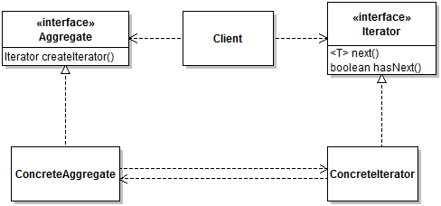

Iterator Pattern - Abstract

An important note about this pattern is that the client does not need to interact with a concrete iterator. Typically in Java, iterator objects will be instances of anonymous classes.

**Example:**

In the case of the iterable version of the `Deck` class, we instantiate the pattern as follows:

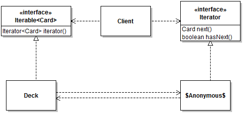

Iterator Pattern - Concrete

### 2.3.8 The Strategy Design Pattern

It also turns out that the use of a function object like the comparator is an instance of a pattern called the [Strategy Pattern](https://en.wikipedia.org/wiki/Strategy_pattern).

**Context:** "Define a family of algorithms, encapsulate each one, and make them interchangeable. Strategy lets the algorithms vary independently from clients that use it." [GoF]

**Solution:**

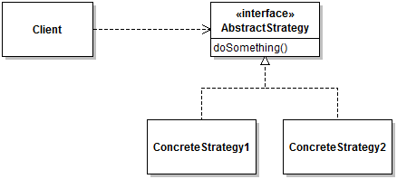

Strategy Pattern - Abstract

The Strategy design pattern looks exceedingly simple. In fact in many cases it can be indistinguishable from a basic use of polymorphism. I find it useful to think of a part of the design as an instance of the Strategy pattern when that part of the design is focused on allowing the switch between algorithms. One example, illustrated below, is the use of different card comparators for a deck of cards. Another example is the implementation of different playing strategies for a computer player.

Although nominally simple, in practice instantiating a Strategy pattern requires thinking about many design questions:

- Does a strategy need one or multiple methods to define the algorithm? Typically the answer is one, but in some more complex cases it may be justified to have more.
- Should the strategy method return anything or have a side-effect on the argument?
- Does a strategy need to keep state or can it be purely stateless?
- What should be the type of the return value and/or method parameters, as applicable? Ideally we want to choose these types to minimize coupling between a strategy and its client(s).

**Example:**

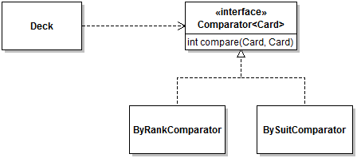

Here the design of the Strategy interface is already decided because we are reusing the `Comparator` interface. This strategy is purely functional as it does not have any side-effect and returns the result of applying the (comparison) algorithm. At this point it should become a bit clearer that implementing the `Comparator` interface as a `UniversalComparator` that holds a value to decide what kind of comparison to do, is not a proper instances of the Strategy pattern.

### 2.3.9 The Interface Segregation Principle

Throughout this module we saw the importance of defining specialized interfaces that specify a small and coherent slice of behavior that clients depend on. This way clients are not coupled with the details of an implementation, but only the methods they actually require. For example, the `Collections.sort` method works because it can rely on just the fact that the items in the collection are `Comparable`. This idea is actually an instance of a general design principle called the *Interface Segregation Principle*. Simply put, the ISP states that *clients should not be forced to depend on interfaces they do not need*.

The idea of the ISP is easier to explain by presenting a situation where the principle is *not respected*. Consider the following problem domain that models some of the tasks of a university processor.

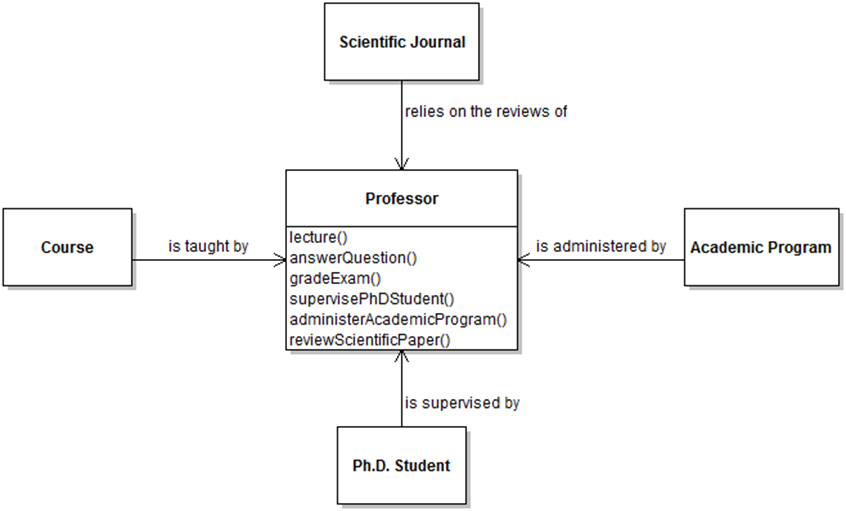

Not using the ISP

If, in a software system supporting this domain, the various clients depend directly on (are tightly coupled to) instances of a `Professor` class, the following two problems surface:

- Clients depend on services they do not need. For instance, `Course` depends on a class that supplies a service `reviewScientificPaper`. This situation is at best confusing, but in worse cases it would limit further changes to the design of the system, because with the current interface, to be able to lecture the object also needs to supply an implementation of a service for reviewing papers.
- It prevents the two virtues of polymorphism stated above, namely **extensibility** and **loose coupling**. For instance, with this design it is not possible to have any object besides an instance of `Professor` provide the `lecture` functionality. In practice this could be done by faculty lecturers or sessional instructors, etc.

The following design respects the ISP:

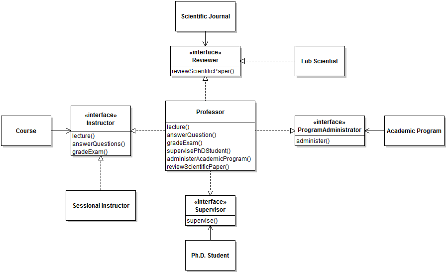

This design is much improved because now instead of depending on a complete implementation, clients depend on *interfaces* that represent specific *roles* directly relevant to each client. Although it's still possible to have a single class implement *all roles* (like a `Professor` instance), it's now also possible to supply different implementations for only a given interface (as in the case of `SessionalInstructor` or `LabScientist`).

What this means in practice for your design activities is that whenever you include, as part of your design, a relation between two classes, it's important to consider whether the client class really needs to depend on the entire interface to the server class, or whether it should only depend on a *role* that objects of this class will fulfill. In the latter case, it makes sense to define a new interface for that class, and have the client depend only on the interface. This is a common design operation called *extracting an interface from a concrete type*. Eclipse provides advanced tool support for extracting interfaces, which you can access through the `Refactoring` menu.

## 2.4 Reading

- [Module 2 Code Samples](https://github.com/prmr/SoftwareDesignCode/tree/master/module02/ca/mcgill/cs/swdesign/m2)
- Solitaire v0.3 PlayingStrategy.java as a simple example of a Strategy interface;
- JetUML v1.0 SegmentationStyle.java as a more elaborate example use of the Strategy Design Pattern.

## 2.5 Exercises

Exercises prefixed with :star: are optional, more challenging questions aimed to provide you with additional design and programming experience. Exercises prefixed with :spades: will incrementally guide you towards the ultimate completion of a complete Solitaire application.

For maximum learning effectiveness, I recommend peeking at the answers only after giving the problems an honest try.

1. Design and implement a well-encapsulated abstraction to represent a "hand" of cards in a player's hand as a Java class `Hand`. A `Hand` should be able to contain between 0 and `N` cards, where `N` is a a parameterizable upper bound that will depend on the card game being played (e.g., 5 for draw poker, 13 for bridge, etc.). Implement the following services on a `Hand`: `add(Card)`, `remove(Card)`, `contains(Card)`, `isEmpty()`, `size()`, and `isFull()`. Find a way to provide access to the cards in the hand. Ensure that all the rules of encapsulation seen in Module 1 are respected and use Design by Contract to clarify valid and invalid inputs.
2. Make is possible to compare two hands using the [Comparable](http://docs.oracle.com/javase/8/docs/api/java/lang/Comparable.html) interface. Sort hands by increasing number of cards in the hand. Write a small driver program to test your class. You do not need to handle the case where the argument is `null`. How to handle this case properly requires the material of Module 7.
3. :star: Modify your `Hand` class to support a poker game and sort hands in terms of their strengths as [poker hands](https://en.wikipedia.org/wiki/List_of_poker_hands). How should you deal with hands that do not have exactly five cards?
4. Make is possible to compare two hands using the [Comparator](https://docs.oracle.com/javase/8/docs/api/java/util/Comparator.html) interface. Implement two different hand comparison strategies. Define *factory methods* in the `Hand` class to return anonymous instances of comparators for the different sorting strategies. You do not need to handle the case where the argument is `null`. How to handle this case properly requires the material of Module 7.
5. Implement a `UniversalComparator` that stores the type of desired comparison as an enumerated type, and switches on that type.
6. :spades: Create a fresh Eclipse project named "Solitaire" (e.g., by copying the [COMP303Starter repo](https://github.com/prmr/COMP303Starter). Add this project to a git repository and create a new package `comp303.solitaire.cards`. Copy the 3 files of the [Solitaire `cards` package](https://github.com/prmr/Solitaire/tree/v0.3/src/ca/mcgill/cs/stg/solitaire/cards) into your own package and adjust the package statements as required. You should now have a fully compilable version of the first three classes of the Solitaire application.
7. :spades: Design a well-encapsulated class to represent "suit stacks". A "suit stack" is a stack where players accumulate finished sequences of cards of a same suit, with the Ace at the bottom and subsequent cards on top of it in strictly increasing order of rank. Call your class `SuitStack`. Try to anticipate the services this class will need, and implement them as methods of the class.
8. Objects of class `Hand` aggregate exactly 10 objects of class `Card`. Implement the mechanism necessary to support sorting hands using the `Arrays.sort` functionality of the JDK. The required behavior for comparing hands is that hands should be ordered in terms of number of cards of a certain rank. Clients should be able to compare hands by number of aces, or number kings, or number of fours, etc. For example, if the client chooses to compare hands by number of aces, a hand with one ace should come before a hand with two aces. If two hands have the same number of aces, they should be considered equal and their order does not matter. The same logic applies to any rank. To answer this question, create the UML class diagram with all relevant elements, and write the code of the method or methods that implement the actual comparison. Your solution should include, among others, the Strategy design pattern and a method that acts as an object factory.
9. Create a UML Class Diagram that captures the main design decisions of JetUML class [SelectionList](https://github.com/prmr/JetUML/blob/v1.0/src/ca/mcgill/cs/stg/jetuml/framework/SelectionList.java) as an aggregator of graph elements. Note that this question will be both easier and more fun to complete if you have a cloned copy of the project's repository in your Eclipse workspace (see Module 0 for instructions on how to access the JetUML code). Hint: you don't need to understand all the details of the class to be able to complete this exercise.

## 2.6 Answers

Answers and answer sketches to the Module 2 practice exercises.

### 2.6.1 Exercises 1, 2, 3, 4, and 8

The code can be found here.

### 2.6.2 Exercise 5

**Hints:** Your comparator class should have a field of an enumerated type, a way to set the value of the field, and use this value in the `compare` method.

### 2.6.3 Exercise 6

You can also clone the [Solitaire GitHub repo](https://github.com/prmr/Solitaire) and delete the Java files to give yourself a fresh start.

### 2.6.4 Exercise 7

Sample answers can be found in the [Solitaire GitHub repo](https://github.com/prmr/Solitaire). Note that in my solution I bypassed the creation of individual `SuitStack` classes and managed everything through a single `SuitStackManager`. However, it's not a bad idea to try it as suggested first.

### 2.6.5 Exercise 9

Since this is a model, small variants are possible. For example, the model would also be correct and useful without the interfaces `Edge` and `Node`. I added them because I thought that was a neat way to answer the question "What is a `GraphElement`?". I also only included a subset of the methods in `SelectionList` which I thought gave the best idea of how the class "worked", and left out a bunch of state querying methods.

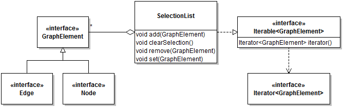

# 3 Module 3 - Object State

## 3.1 Description

The most difficult thing to reason about when looking at a program is state changes. What operations can have a side-effect, on which path can data flow, what impacts what? Is this module, I will clarify what object state is and how we can manage to keep control over its state in a principled way so we don't let the genie out of the bottle every time we instantiate an object.

## 3.2 Learning Objectives

After this module you should:

- Understand the difference between a static and dynamic perspective on software;
- Understand the meaning and implications of shared state and unique objects;
- Understand the difference between the concepts of object identity and object equality, and their implications for software design;
- Be able to correctly and effectively use the methods of the `Object` class;
- Be able to effectively use the Singleton and Flyweight design patterns;
- Be able to effectively use UML State Diagrams to reason about the abstract states of complex stateful objects;
- Be able to correctly use Java's cloning mechanism;

## 3.3 Notes

### 3.3.1 General Concepts and Definitions

There are different way we can look at a software system. One way is in terms of the software elements declared in the source code and the relations between them. For example, a `Deck` class declares a field `aCards` that is a stack of `Card` instances. This is a **static view** of the system. The static view is best represented by the source code or a UML class diagram. A different, but complementary, way to look at a system, is in terms of *values* and *objects* in a running program. For example, at one point a `Deck` contains three cards, then one card is drawn, which leads to the instance of `Deck` containing two cards. This is the **dynamic (or run-time) view** of the system. The dynamic view corresponds to what we see in a debugger while stepping through the execution of a program. The dynamic view *cannot* easily be represented by any one diagram. Instead, we rely on object diagrams, *state diagrams* (introduced in this module), and *sequence diagrams* (introduced in Module 5). The static and dynamic views are two complementary perspectives in software design. Sometimes it's best to think of a problem and solution in static terms, sometimes in dynamic terms, and sometimes we really need both. This module focuses on understanding important *dynamic* properties of software.

This duality between the static and dynamic perspective on a software system is akin to the wave-particle duality for representing the phenomenon of light in physics:

> It seems as though we must use sometimes the one theory and sometimes the other, while at times we may use either. […] We have two contradictory pictures of reality; separately neither of them fully explains the phenomena of light, but together they do. - Albert Einstein and Leopold Infeld, The Evolution of Physics, pg. 262-263

So, to paraphrase for software design: It seems as though we must use sometimes the one perspective and sometimes the other, while at times we may use either. We have two *complementary* pictures of a program; separately neither of them fully explains the phenomena of software, but together they do.

An important concept when thinking of a design in terms of run-time objects is that of **object state**. Informally, state refers to the particular pieces of information the object represents at a given moment. It is generally useful to distinguish between *concrete state* and *abstract state*. The **concrete state** of an object is the collection of values stored in the object's fields. For example, if we consider a `BankAccount` object that is simply a wrapper for an `int`:

```java
public class BankAccount
{
   private int aAmount = 0;
   ...
```

the cardinality of the space of possible concrete states for `BankAccount` is `2^32`, or about 4 billion states. As soon as objects have fields of reference types, the size of the state space explodes dramatically. For example, the state space of a `Deck` object includes all possible permutations of any number of cards in the deck, a number in the range of 2e68 (two times 10 to the 68th power). In the case of the `BankAccount` object, adding an `aName` field of type `String` blows up the size of the state space to something that is only limited by the physical memory of the computing system. For this reason, when designing software, it is more practical to think in terms of *abstract states*.

In principle, an **abstract state** is an arbitrarily-defined subset of the concrete state space. For example "even balance" could be an abstract state for the `BankAccount` object that groups the roughly `2^31` states representing an even number of some currency in the account. Likewise for an instance of the `Deck` class, the abstract state "three kings" could represent any possible configuration of the deck where exactly three cards of rank `Rank.KING` are present. These two examples illustrate the fact that because abstract states are *arbitrary* partitions of the state space, they can really be defined as anything. It should however be evident that neither of these two abstract states would be particularly useful for designing a software solution to either the problem of bank management or card game playing. In practice, the software design task is to define abstract states that correspond to characteristics that will help construct a clean solution. A more useful abstract state for `BankAccount` would be "positive balance", and one for `Deck` would be "empty" (no cards in the deck), which in this case corresponds to a single concrete state.

### 3.3.2 UML State Diagrams

**UML State Diagrams** represent a *dynamic*, or *run-time* view of a software system. They are useful to represent how objects can *transition* from one abstract state to another during their lifetime as a reaction to external events (typically, method calls). The annotated diagram below provides all the notation I will be using in the book.

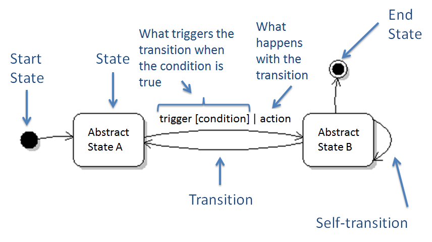

UML State Diagram Cheat Sheet

The following example illustrates both the notation and purpose of UML state diagrams. It models some of the important abstract states of an instance of a class `Deck` that represents a deck of 52 playing cards. Even this simple diagram captures key information about the design of the `Deck` class.

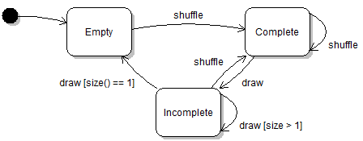

UML State Diagram Example 1

The abstract state `Empty` is annotated as the **start state**, which allows us to infer that the constructor returns a reference to a new deck object with no cards in it.

In UML State Diagrams, **absence of a transition** usually means that the absent transition is *invalid* for that state. Here we can see that we cannot `draw` cards from an empty deck. Note that the transitions are annotated with names that correspond to methods of the class `Deck`. The only **legal transition** out of the `Empty` state is `shuffle` which brings the object in the `Complete` state. From this it can easily be inferred that "Complete" is a shorthand for "Complete and shuffled" (in this particular design).

It is also possible to annotate transitions with an **action** that describes what happens as the result of the transition. The action that corresponds to the `draw` event is "remove card from the deck". The action information is optional and here I chose to leave it out of the diagram because it is obvious, and therefore adds no value to the diagram.

The two transitions out of the `Incomplete` state illustrate the importance of **conditions**, because here without the concept of a condition we would not be able to model the distinction between a `draw` event that leads to the `Empty` state, and a `draw` event that keeps the object in the `Incomplete` state. In this book, the language I use for modeling conditions does not need to follow a formal specification, but I nevertheless like to specify the conditions using pseudo-code that is very close to what could be reasonably tested on an instance of the object. Here the conditions would assume the presence of an (at least private) `size` method in the `Deck` class.

Finally, this diagram does not include any **end state**. The end state model element is used to specify if an object *must* be in a certain state at the end of its lifetime (i.e., in Java, when it is garbage collected). In many designs, objects can end their life (stop being used) in any state, in which case the end state model element does not apply.

An important benefit of State Diagrams is that they allow us to self-evaluate the impact of design decisions on the complexity of the abstract state space that must be considered when working with an object. Here the state space is very simple (3 states) *because of the decision to bundle the deck initialization code together with the shuffling code*. Separating this behavior into distinct `initialize` and `shuffle` events, or including a `sort` event, leads to a much more complicated state space for the object.

Another important benefit of State Diagrams is that it supports a systematic reasoning about the behavior of an object of a given class. When modeling the state of an object, a good practice is to visit each state and consider each possible type of event. This simple procedure is an excellent way to avoid overlooking certain paths through a program (e.g., shuffling an incomplete deck).

When getting started with modeling object state with UML State Diagrams, one common tendency is to use the state diagram notation to model a type of "data-flow" information, where states represent "processing", and arrows represent the flow of data between processing stages. This is an incorrect use of the notation. A good tip for avoiding this pitfall is to think about the names of the states. If the names assigned to "states" include verbs or generally feel like they are describing actions (e.g. "draw card"), it is probably a sign that the diagram does not represent a good model of the state space.

Finally, it will be readily apparent that the concept of state diagram is very similar to that of [Deterministic finite automata (DFA)](https://en.wikipedia.org/wiki/Deterministic_finite_automaton). This is not a coincidence, as both notations are intended to model some sort of stateful phenomenon. However, the purpose of each notation is different. While the purpose of DFAs is to support the formal modeling of computation, the purpose of UML state diagrams is to support software engineering tasks such as software design, testing, and documentation.

### 3.3.3 Object Identity, Equality, and Uniqueness

Three important concepts to keep in mind when designing with objects are those of *identity*, *equality*, and *uniqueness*.

**Identity** refers to the fact that we are referring to a particular object, even if this object is not in a named variable. In terms of programming environments, the identity of an object usually refers to its "memory location". However, in modern programming systems the memory management of objects is heavily abstracted, and for this reason it's best to simply think in terms of object identity. Most integrated development environments will supply a convenient handle to represent an object's identity. For example, in the Eclipse debugger this is represented by the object id.

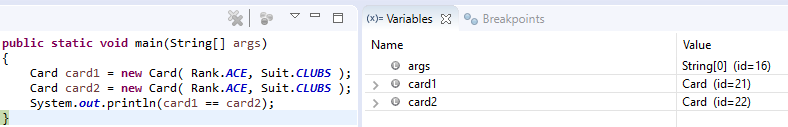

Object Identity Example

In this small example two `Card` objects are created, and consequently result in two distinct objects with two distinct identities, represented with internal object identifiers 21 and 22. In the object diagram below, the `main` method and its two variables is represented as an object. The diagram shows how object identity corresponds to both object model elements and the references to these objects. If, for instance, a reference to the `Card` object with id 21 is added to a list, there will be two shared references to a single identity.

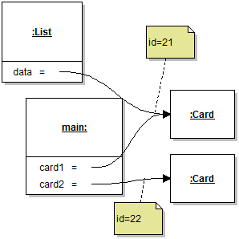

Object Identity Example

The last statement in the `main` method, in the figure above, is a reminder that in Java, the `==` returns `true` if the two operands evaluate to the same value. In the case of values of reference types, "the same value" means referring to the same object (identity). So here the statement returns false because, although both cards represent an ace of clubs, they are references to distinct objects.

The situation above, where two distinct `Card` objects represent the ace of clubs, illustrates the concept of **object equality**. In the general case, *equality* between two objects must be programmer-defined because the meaning of equality cannot always be inferred from the design of the object's class. In simple cases (like objects of class `Card`), one could say that two objects are *equal* if all their fields have the same value, but for many objects of more complex classes, this would be too strict. For example, if some objects cache values or have non-deterministic internal representations, they could be "equal" in the practical sense, without having *precisely* the same value for each field, transitively.

For this reason, Java provides a mechanism to allow programmers to specify what it means for two objects of a class to be equal. This specification is realized by *overriding* the [equals](http://docs.oracle.com/javase/8/docs/api/java/lang/Object.html#equals-java.lang.Object-) and [hashCode](http://docs.oracle.com/javase/8/docs/api/java/lang/Object.html#hashCode--) methods. The default implementation of the `equals` method defines *equality as identity*. In other words, if the `equals` method is not redefined for a class, `a.equals(b)` is the same as `a == b`. In many situations, like our example of playing cards, this is not what we need, and we must supply our own implementation of the `equals` method. Implementations of `equals` can usually follow this example as a template:

```java
public boolean equals(Object pObject)
{
   if( pObject == null ) // As required by the specification
   {
      return false;
   }
   else if( pObject == this ) // Performance optimization
   {
      return true;
   }
   else if( pObject.getClass() != getClass()) // Ensures the objects are of the same class
   {
      return false;
   }
   else // Actual comparison code. Assumes the downcast is safe.
   {
      return aRank == ((Card)pObject).aRank && ((Card)pObject).aSuit == aSuit;
   }
}
```

We will revisit some of the details of the overriding mechanism in Module 7. For now, it suffices to say that if the `equals` method is *redefined* (or *overridden*) in a class, calling `equals` on an object of this class will result in the redefined method being executed. In our case,

```java
card1.equals(card2)
```

will return `true`.

A very important note when overriding `equals` in Java, is that any class that overrides `equals` must also override `hashCode` so that the following constraint is respected: "If two objects are equal according to the `equals(Object)` method, then calling the `hashCode` method on each of the two objects must produce the same integer result." [[Javadocs]](http://docs.oracle.com/javase/8/docs/api/java/lang/Object.html#hashCode--). This constraint is necessary because, among other, many classes of the collections framework rely interchangeably on equality testing and on an object’s hash code for indexing objects in internal data structures.

A final consideration related to identity and equality is the concept of **uniqueness**. In our example program, we could rightfully wonder what is the point of tolerating duplicate objects that represent exactly the same card (e.g., ace of clubs). A sometimes very useful property for the objects of a class is *uniqueness*. Objects of a class are unique if it is not possible for two distinct objects to be equal. If the objects of a class can be guaranteed to be unique, then we no longer need to define equality, because in this specific case, equality become identical to identity and we can compare objects using the `==` operator. Although strict guarantees of uniqueness are almost impossible to achieve in Java due to mechanisms such as reflection and serialization, in practice the use of two design patterns and the conscious avoidance of these mechanisms provides a "pretty good" guarantee that can help greatly simplify some designs.

### 3.3.4 Sharing References with Anonymous Classes and Lambda Expressions

Module 1 introduced the concept of *encapsulation*, and this module focused on the careful management of objects and their state. One common programming language feature, *anonymous classes and functions* requires careful consideration to ensure references to objects are not shared by accident.

As demonstrated in the code of Hand.createByRankComparator, methods of Java anonymous classes have access to an interesting scope that seems to include the local variables of the parent method.

```java
public static Comparator<Hand> createByRankComparator(Rank pRank)
{
   return new Comparator<Hand>()
   {
      @Override
      public int compare(Hand pHand1, Hand pHand2)
      {
         return countCards(pHand1, pRank) - countCards(pHand2, pRank);
      }
      ...
   };
}
```

Upon closer inspection, it appears that the code of method `compare` *declared inside the anonymous class* has access to the parameter `pRank` of `createByRankComparator`, which is a *separate method in a separate class*. What could pRank possibly refer to when the program is running? Once the `createByRankComparator` method returns an object, this object has its own life-cycle that is completely independent from that of the `Hand` object. Yet this is legal, compilable code, that actually works.

Because referring to variables in the parent methods from an anonymous class is such a useful programming idiom, it is fully supported by the compiler. To make this work, when the compiler creates the definition of the anonymous class, it also (invisibly) adds *fields* to the anonymous class, and copies references to each of the local variable referenced in the code of the anonymous class's method into a field. Thus, once an object of the anonymous class is created, the references to the local variables are now stored in fields of the same name in the anonymous class. The object diagram below illustrates this idea:

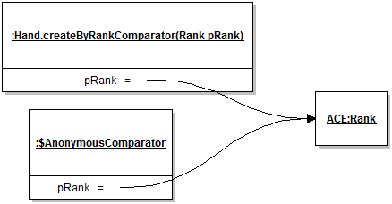

Closure Example

In this diagram the factory method is represented as a separate object with field `pRank` used to represent its parameter. This method returns a completely new object of an anonymous class. So that the `compare` method can still refer to the `pRank` parameter, a field `pRank` is created in the instance of the anonymous comparator, and the value of `pRank` is copied to it. A method definition together with references to its local environment variables is commonly called a closure. As the object diagram shows, it should be clear that closures can easily lead to shared references between object instances. To prevent unexpected behavior, Java prevents reassigning local variables that are referenced in anonymous classes. In Java 7 and earlier, local variables referenced in anonymous classes had to be declared `final`. With Java 8 the compiler can infer variables to be *effectively final* without the keyword. In any case, the point of this appendix is to emphasize that sharing references to objects through closures is still sharing references to objects, and when the shared objects are mutable, one should keep in mind that it can weaken encapsulation.

### 3.3.5 The Flyweight Design Pattern

The [Flyweight Pattern](https://en.wikipedia.org/wiki/Flyweight_pattern) is provides a useful way to cleanly manage collections of low-level immutable objects. Although often use to address *performance concerns*, the Flyweight is also valuable to ensure the uniqueness of objects of a class.

**Context:** Instances of a class are heavily shared and compared throughout the software system.

**Solution:**

The general idea is to manage the creation of objects of a certain class, call the `Flyweight` class, through a factory method. The three main components of the Flyweight pattern are:

1. A private constructor for the Flyweight, so clients cannot control the creation of objects;
2. A data structure that keeps a list of Flyweight instances, stored in a static field;
3. A static factory method that returns the unique Flyweight object that corresponds to the input parameter.

**Example:**

See Solitaire v0.3: [Card](https://github.com/prmr/Solitaire/blob/v0.3/src/ca/mcgill/cs/stg/solitaire/cards/Card.java).

**Discussion:**

An important concern when implementing the Flyweight pattern is whether to pre-initialize the flyweight objects, or whether to do this lazily, by creating objects as they are requested through the factory method. The answer is problem-dependent. In general, in cases where there exists a small and finite set of flyweights, it may make sense to pre-initialize them (as in the example). In other cases, additional logic must be added to the factory method to check if the object exists in the collection. It is also important to note that Flyweight objects should be *immutable* to ensure that they can be shared and compared throughout the program.

### 3.3.6 The Singleton Design Pattern

The Singleton design pattern provides a principled way to ensure that there is *only one instance of a given class* as any point in the execution of a program. This design pattern is useful to simplify the access to stateful objects that typically assume the role of a controller of some sort.

**Solution:**

1. A private constructor for the Singleton, so clients cannot create duplicate objects;
2. A static final field keeping a reference to the single instance of the singleton object.
3. A static accessor method, usually called `instance()`, that returns the unique instance of the Singleton.

**Discussion:**

The Singleton pattern differs from the Flyweight in that it attempts to guarantee that there is *a single instance of a class*, as opposed to *unique instances of a class*. Singleton objects are typically stateful, whereas Flyweights should be immutable.

A typical mistake when implementing the Singleton pattern is to store a reference to an instance of the class in a static field called `INSTANCE` or something like it, without taking proper care to prevent client code from independently creating new objects. For example, class `ClosedInputStream` of the Apache Commons IO library defines a ["singleton" field](https://github.com/apache/commons-io/blob/ffcbfdc80ed7ca7ffce883f615f710beabd9e06c/src/main/java/org/apache/commons/io/input/ClosedInputStream.java#L36), but the class is not really a singleton because it is re-instantiated in different parts of the library, for example [here](https://github.com/apache/commons-io/blob/ffcbfdc80ed7ca7ffce883f615f710beabd9e06c/src/main/java/org/apache/commons/io/input/CloseShieldInputStream.java#L49) and [here](https://github.com/apache/commons-io/blob/ffcbfdc80ed7ca7ffce883f615f710beabd9e06c/src/main/java/org/apache/commons/io/input/AutoCloseInputStream.java#L65). In this case, use of the Singleton name is harmfully misleading, because users of the library may rely on the fact that the class supports a single instance when it does not.

```java
public enum GameEngine
{
   INSTANCE;

   public void initializeGame() {}
}
```

This technically works because the compiler will prevent the instantiation of enumerated types. Although this approach is represented as "preferred" in Effective Java, it is not without detractors, as evidenced by [this Reddit thread](https://www.reddit.com/r/java/comments/60mk1z/implementing_singleton_as_enum/) and [this blog](https://closingbraces.net/2011/07/04/enum-as-singleton/). My conclusion is that this strategy is a trick that uses a programming mechanism (enum types) for an intent other that originally designed, and as such can be confusing. Here the type `GameEngine` is not a finite set of values that represent different game engines, which is what one would initially expect when seeing an `enum` designation. The enum trick also closes the door to subclassing the `Singleton`, although this variant is explicitly discussed in the [original design pattern book](https://openlibrary.org/books/OL7408317M/Design_Patterns). I thus recommend sticking to a private constructor to ensure the single instance constraint.

### 3.3.7 A Review of Object Characteristics

[output not shown]

## 3.4 Reading

- Solitaire v0.3: [Card](https://github.com/prmr/Solitaire/blob/v0.3/src/ca/mcgill/cs/stg/solitaire/cards/Card.java) as an example of the Flyweight pattern in action.
- Solitaire v0.3: [CardImages](https://github.com/prmr/Solitaire/blob/v0.3/src/ca/mcgill/cs/stg/solitaire/cards/CardImages.java) as a different example of the Flyweight pattern in action.
- JetUML v1.1: [Commit cf2d37e](https://github.com/prmr/JetUML/commit/b6531f48d330ee6ab96e944a5837cefc2cf2d37e) as a concrete example of a refactoring to make a class a Singleton.

## 3.5 Exercises

Exercises prefixed with :star: are optional, more challenging questions aimed to provide you with additional design and programming experience. Exercises prefixed with :spades: will incrementally guide you towards the ultimate completion of a complete Solitaire application.

For maximum learning effectiveness, I recommend peeking at the answers only after giving the problems an honest try.

1. Create a UML State Diagram that models the abstract states of a hypothetical `Dryer` object that behaves as follows. *The dryer is normally off. To get it to operate you have to put in 2.00$. Once the money is inserted, you cannot add additional credit until the drying is over. The mechanism to insert the money only allows you to put the exact amount in one go. To start the machine once the money is inserted, you have to close the door and press the start button. The dryer will then operate for exactly 60 minutes, and then stop by itself. If you open the door while it’s in operation, the dryer will stop and whatever time was left is lost.*
2. Create a UML State Diagram that models the abstract states of a hypothetical `VendingMachine` object that behaves as follows. *The machine sells a selection of different drinks. All drinks have a price, not necessarily the same. If a user selects a drink, the price is displayed. If the user adds enough coins within 60 seconds, the drink is provided and change is returned. If a user adds coins without selecting a drink, the available balance is shown. If a user selects a drink that is worth less than the balance, the drink is provided and changed is returned. If not, an error message shows "insufficient balance". A reset button resets any selection and returns the balance.*
3. Change the design of your `Card` class to ensure the uniqueness of its instances through the use of the Flyweight Design Pattern.
4. :spades: Design and implement a class `WorkingStack` that manages the state of one of the working stacks in Solitaire. Note that as opposed to the `SuitStack` designed in Module 2, for `WorkingStack` you have to solve the problem of remembering which card is visible (or face up), and which card is not.
5. :spades: Using the Singleton Design Pattern, design a `GameModel` class that is a Singleton.
6. :spades: Complete the design of the `GameModel` class. This class will be responsible for managing all the necessary state for a game of solitaire. The class should offer the following state-changing services (through methods): `reset()` initializes a new game by clearing all the working stacks, shuffling the deck, and placing cards on the working stack according to the rules of solitaire (one card on the first stack, two on the second, etc., with the top card of each stack visible); `move(Card, Location)` Moves a card from an assumed legal playing position to the specified location (to be designed); `discard` Moves a card from the top of the deck to the top of the discard pile. In addition, the `GameModel` should provide all the necessary state-querying services, including methods to check the state of the deck and the discard pile (empty or nor), view the cards in the different stacks, etc. In particular, the `GameModel` class should provide a method `getScore()` that returns the cumulative number of cards in the four suit stacks. A score of 52 indicates a win.
7. :spades: Create a UML Class diagram that illustrates the most important elements of your implementation of the `GameModel` class;
8. :spades: Create a UML State diagram that captures all the main abstract states of an instance of the `GameModel` class, and the transitions between them;
9. :spades: Using the Strategy Design Pattern, add an `autoplay()` method to the `GameModel`, whose purpose is to automatically perform a legal move, if possible. Carefully consider how the strategy should work (inputs, outputs). Consider using the interface segregation principle to decouple the strategy from the `GameEngine`.
10. :spades: :star: Implement, in a main method somewhere (where?), a small driver program that automatically plays N games and reports the average final score per game and the percentage of games won. If, for N=10,000, you get above 2% win or 9 points per game on average, make sure to let the instructor know.

## 3.6 Answers

Answers and answer sketches to the Module 3 practice exercises.

### 3.6.1 Exercise 1

The key insight here is that the state of the door (open or closed) needs to be reflected in the modeled abstract states. Note that the state diagram captures information on how the "start" button works. Because every state has a transition labeled "start", it means it's always possible to press the "start" button, it simply happens to do nothing except in the case where there's a balance and the door is closed. Not including the "start" self-transitions would actually be a different specification for the machine. It would mean that it is physically impossible to press the button except when it can start the machine (in the sense that the button is mechanically blocked or something). Assuming whoever uses the machine actually wants to get their dry laundry back, it makes sense to include an end state.

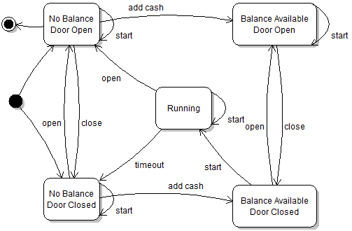

### 3.6.2 Exercise 2

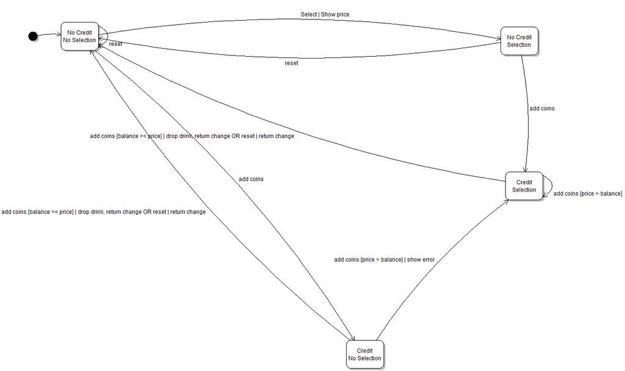

### 3.6.3 Exercise 3

See the implemented [Card](https://github.com/prmr/Solitaire/blob/v0.3/src/ca/mcgill/cs/stg/solitaire/cards/Card.java) class. Note that there are different ways to implement the Flyweight collection. An alternative would be using lazy initialization of a double hash table.

### 3.6.4 Exercise 4

**Sketch:** You can implement a class `WorkingStack` that is a wrapper for a `java.util.Stack`. To record which card is visible or not, many different strategies are possible. For example, you could have a separate field `aVisible` of type `Set<Card>` in which you add cards as they become visible. The sample [WorkingStackManager](https://github.com/prmr/Solitaire/blob/v0.4/src/ca/mcgill/cs/stg/solitaire/model/WorkingStackManager.java) in the completed Solitaire application does things a bit differently, by managing all working stacks through a single class, which is slightly different from what is required for this exercise.

### 3.6.5 Exercise 5

The minimum necessary to realize the Singleton pattern is as follows:

```java
public final class GameModel implements GameModelView
{
   private static final GameModel INSTANCE = new GameModel();

   /**
    * @return The singleton instance for this class.
    */
   public static GameModel instance()
   {
      return INSTANCE;
   }
}
```

### 3.6.6 Exercise 6

See the fully implemented [GameModel](https://github.com/prmr/Solitaire/blob/v0.4/src/ca/mcgill/cs/stg/solitaire/model/GameModel.java) for a sample.

# 4 Module 4 - Unit Testing

## 4.1 Description

How can we have confidence that our code is working properly? Every time we write or change a line of code, we could be introducing a lethal bug. *Unit testing* is a practice wherein we automatically execute our code to check that it does what we think it should. With unit testing, we can build a possibly large collection of tests that can quickly be run, for instance every time we change the code, to make sure we didn't break anything that used to work. In this module, I will introduce mechanisms that facilitate unit testing (reflection and type annotations) and provide you with basic techniques for designing unit tests and evaluating their quality.

## 4.2 Learning Objectives

After this module you should:

- Be able to explain the foundational concepts of testing using the proper terminology;
- Understand type annotations and program reflection and be able to use them effectively;
- Be able to write unit tests with JUnit;
- Be able to approach more advanced testing problems requiring reflection or mock objects;
- Be able to understand the output of a test coverage tool such as EclEmma;
- Be able to understand basic test suite adequacy criteria and the relations between them;

## 4.3 Notes

### 4.3.1 General Concepts and Definitions

Software quality problems are often caused by programmers writing code that doesn't quite do what they expect. For example, this [bug](https://github.com/prmr/JetUML/issues/188) in JetUML made it impossible to see the directory structure in a file chooser object because of an incorrect *compound* (i.e., multi-part) condition.

One way to detect bugs, and to gain confidence that a part of a program does what we expect, is to *test* it. [Testing](https://en.wikipedia.org/wiki/Software_testing) in the general sense is a software quality assurance technique that can take many forms. In the context of an introduction to software design, I will be using a specific testing approach called [Unit testing](https://en.wikipedia.org/wiki/Unit_testing). The idea of unit testing is to test a very small part of the program in isolation. This way, if the test fails, it is easy to know where to look for problems.

In practice, a **unit test** consists in one execution of a **unit under test (UUT)** with some **input data** and the comparison of the result of the execution against some **oracle**. For example, the statement:

```java
Math.abs(5) == 5;
```

technically qualifies as a test. Here the UUT is the library method `Math.abs(int)`, the input data is the integer 5, and the oracle is, in this case, also the value 5. When testing non-static method, it's important to remember that the input data includes the receiver object (the object that receives the method call).

Although it is possible to test a system manually, in practice unit testing is done automatically. Since in software development the way to automate anything is to write a program to do it, to automate software testing we also write code to test other code.

This task is typically supported by a **unit testing framework** like [xUnit](https://en.wikipedia.org/wiki/XUnit), which in the case of Java means JUnit. JUnit automates a lot of the mundane parts of unit testing, including collecting tests, running them, and reporting the results.

### 4.3.2 Basics of JUnit

In JUnit a unit test maps to a method. The code below illustrates a very simple unit test with JUnit.

```java
public class AbsTest
{
   @Test
   public void testAbsPositive()
   {
      assertEquals(5,Math.abs(5));
   }

   @Test
   public void testAbsNegative()
   {
      assertEquals(5,Math.abs(-5));
   }

   @Test
   public void testAbsMax()
   {
      assertEquals(Integer.MAX_VALUE,Math.abs(Integer.MIN_VALUE));
   }
}
```

The `@Test` [Annotation](https://docs.oracle.com/javase/tutorial/java/annotations/index.html) indicates that the method should be run as a unit test. This annotation is defined in the JUnit library, which must be added to a project's classpath before it is visible. The test method should typically contain at least one call to a UUT. The way to automatically verify that the execution of a UUT has the expected effect is to execute various calls to `assert*` methods. Assert methods are different from the `assert` statement in Java. They are declared as static methods of the class `org.junit.Assert*` and all they do is basically verify a predicate and, if the predicate is not true, report a *test failure*. The JUnit framework includes a GUI component called a *test runner*. To execute the JUnit test running from within Eclipse, right-click on a project that contains at least one JUnit test method, and select `Run As | JUnit Test`. When executing, all the JUnit test runner does is inspect the program, collect all methods flagged as unit tests using annotations, invoke them, then report whether the tests passed or failed.

For additional instructions on how to use JUnit, read [this tutorial](http://www.vogella.com/tutorials/JUnit/article.html). To fully understand how JUnit works it is necessary to first read the [Annotations](https://docs.oracle.com/javase/tutorial/java/annotations/index.html) and [Reflection](https://docs.oracle.com/javase/tutorial/reflect/) tutorials.

### 4.3.3 Test Suite Organization

A collection of tests for a project is known as a **test suite**. A common question is how to organize our tests in a sensible manner. There are different approaches, but in Java a common way to organize tests is to have one *test class* per *project class*, where the test class collects all the tests that test methods of that class. Furthermore, it is common practice to locate all the testing code in a different *source folder* with a package structure that *mirrors the project's package structure*. The rationale for this idiom is that in Java classes in the same package are in the same *package scope* independently of their location in a file system. This means that classes and methods in the test package can refer to non-public (but non-private) members of classes the project code. This strategy simplifies the test code. The figure below illustrates this idea.

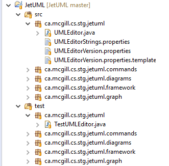

Test Suite Organization

### 4.3.4 Test Fixtures

In test classes that group multiple test methods, it will often be convenient to define a number of "default" objects or values to be used as receiver objects and/or oracles. This practice will avoid the duplication of setup code in each test method. Baseline objects used for testing are often referred to as a *test fixture*, and declared as fields of a test class. However, when designing a test suite with JUnit, is it extremely important to know that JUnit *provides no ordering guarantee of any kind* for the execution of unit tests. In consequence, unit tests must be independent of each other so that they can be executed in any order. This further implies that no test method should rely on the fixture being left in a given state by another test. In most cases this precludes the use of the class constructor to initialize the fixture, because the constructor is only called once. The workaround is to nominate a method of the test class to execute before any test method. In JUnit this method is nominated using te `@Before` annotation. Fixture initialization code should therefore be located in this method. The use of test fixtures in JUnit is illustrated by most test classes in both sample projects. For example, in the Solitaire application's [TestSuitStackManager](https://github.com/prmr/Solitaire/blob/master/test/ca/mcgill/cs/stg/solitaire/model/TestSuitStackManager.java) class, the fixture consists of a single field `aSuitStackManager` which is initialized with a fresh object in method `setup`:

```java
@Before
public void setup()
{
   aSuitStackManager = new SuitStackManager();
}
```

which is executed before the execution of every `@Test`-annotated method.

### 4.3.5 Tests and Exceptional Conditions

An important point when writing unit tests is that what we are testing is *that the UUT does what it's supposed to*. This means that when using design by contract, it does not make sense to test code with input that does not respect the UUT's preconditions, because the resulting behavior is *unspecified*. For example, for method [peek](https://github.com/prmr/Solitaire/blob/master/src/ca/mcgill/cs/stg/solitaire/model/SuitStackManager.java#L104), which has as precondition `assert !aStacks.get(pIndex).isEmpty();`, it would be awkward to try to write a test for an empty stack. What would be the oracle?

The situation is very different, however, when exceptional behavior *is explicitly part of the interface*. For instance, for method [peek](https://docs.oracle.com/javase/8/docs/api/java/util/Stack.html#peek--) of the Java `Stack` class, peeking an empty stack *should* result in an `EmptyStackException`. If it does not, then the `peek` method does not do what is expected, and this means it is faulty.

This situation raises the question of how to test for exceptional conditions. In JUnit there are two idioms. One is to use the `expected` property of the `@Test` annotation:

```java
@Test(expected = EmptyStackException.class)
public void testPeekEmpty1()
{
   Stack<String> stack = new Stack<>();
   stack.peek();
}
```

With this feature, JUnit will automatically *fail the test* if the execution of the corresponding test method completes *without* raising an exception of the specified type. This testing idiom is very useful, but limited in the sense that the exceptional behavior must be the last thing to happen in the test. In cases where it is desirable to execute additional testing code after testing the exceptional behavior, the following idiom can be used:

```java
@Test
public void testPeekEmpty2()
{
   Stack<String> stack = new Stack<>();
   try
   {
      stack.peek();
      fail();
   }
   catch(EmptyStackException e )
   {}
}
```

This idiom is a bit convoluted, but does exactly what we want. If the UUT (the `peek` method here) is faulty in the sense that it does not raise an exception when it should, the program will keep executing normally and reach the following statement, which will force a test failure. If the UUT is (at least partially) correct in that it does raise the exception when it should, control-flow will immediately jump to the catch clause, thereby skipping the `fail();` statement. It is then possible to add additional code below the catch clause.

### 4.3.6 Encapsulation and Unit Testing

A common question when writing tests is, how can we test private methods? There are different possible avenues for answering that question, but experts disagree about which one is the right one:

- Private methods are internal elements of other, accessible methods, and therefore are not really "units" that should be tested. Following this logic, the code in private methods should be tested indirectly through the execution of the accessible methods that call them;
- The `private` access modifier is a tool to help us structure the project code, and tests can ignore it.

Although I understand the rationale of the first approach, I personally fall in the second camp. There are many cases where a neat little method can be restricted to a class's scope, but it would still be valuable to test it in isolation. This situation is exemplified by the tests added to test [this fix](https://github.com/prmr/JetUML/issues/188).

To by-pass the `private` access modifier, it is necessary to use [metaprogramming](https://docs.oracle.com/javase/tutorial/reflect/).

The following code sample illustrates the main steps:

```java
public class TestEditorFrame
{
   private Method aCreateFileFilter;
   private EditorFrame aEditorFrame;

   @Before
   public void setup() throws Exception
   {
      aCreateFileFilter = EditorFrame.class.getDeclaredMethod("createFileFilter", String.class);
      aCreateFileFilter.setAccessible(true);
      aEditorFrame = new EditorFrame(UMLEditor.class);
   }
```

This test class definition includes, as part of its fixture, a field that stores a reference to an instance of class `Method` that represents the private method we want to test. The field is initialized in the `setup` method, and made accessible outside the class scope using the `setAccessible` method. This last part is what bypasses the `private` keyword.

In the test class, we can then define a *convenience method* that launches the execution of the UUT (`createFileFilter`):

```java
private FileFilter createFileFilter(String pFormat)
{
   try
   {
      return (FileFilter) aCreateFileFilter.invoke(aEditorFrame, pFormat);
   }
   catch(InvocationTargetException | IllegalAccessException pException)
   {
      TestCase.fail();
      return null;
   }
}
```

In the methods of the test class, calling `createFileFilter` now has the same effect as calling `createFileFilter` on an instance of `EditorFrame`. This way the rest of the test looks pretty normal:

```java
@Test
public void testCreateFileFilteAcceptDirectory()
{
   FileFilter filter = createFileFilter("PNG");
   File temp = new File("foo");
   temp.mkdir();
   assertTrue(temp.isDirectory());
   assertTrue(filter.accept(temp));
   temp.delete();
}
```

except that it does not directly call the UUT, but a wrapper that uses metaprogramming to call the UUT while by-passing the access restriction of the `private` keyword.

### 4.3.7 Testing with Stubs

The key to unit testing is to test small parts of the program *in isolation*. But what happens if the part we want to test triggers the execution of a large chunk of the program? This situation is illustrated in the following design, which is a simplified version of the Solitaire sample application. The `GameEngine` has an `automove()` method that triggers the computation of the next move by dynamically delegating the task to a strategy, which could be any of the three options. Here we would like to write a unit test for the `GameEngine.automove()` method.

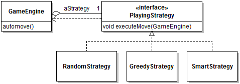

In this task we face at least three problems:

- Calling the `void executeMove(...)` method on any strategy will trigger the execution of presumably complex behavior by the strategy, which possibly depends on many other parts of the code. This does not align well with the concept of unit testing, where we want to test small pieces of code in isolation.
- How can we know which strategy would be used by the game engine? Presumably we need to determine an oracle for the results.
- How is this different from testing the strategies individually?

The way out of this conundrum is the realization that the responsibility of `GameEngine.automove()` is *not* to compute the next move, but rather *to delegate this to a strategy*. So, to write a unit test that tests that the UUT does what it is expected, we *only need to verify that it relays the automove computation to a strategy*. This can be achieved with the writing of a *stub* (a.k.a. [mock object](https://en.wikipedia.org/wiki/Mock_object), although there's no agreement on terminology).

An object stub is a greatly simplified version of an object that mimics its behavior sufficiently to support the testing of a UUT that uses this object. Using stubs is heavily dependent on types and polymorphism (see Module 2). Continuing with our `automove` situation, here we simply want to test that the method calls a strategy, so we will define a dummy strategy in the test method:

```java
public class TestGameEngine
{
   @Test
   public void testAutoPlay() throws Exception
   {
      class StubStrategy implements PlayingStrategy
      {
         private boolean aExecuted = false;

         public boolean hasExecuted() { return aExecuted; }

         @Override
         public void executeMove(GameEngine pGameEngine)
         {
            aExecuted = true;
         }
      }
```

This strategy does nothing except remember that its `executeMove` method has been called. We can then use an instance of this stub instead of a "real" strategy in the rest of the test. To inject the stub in the game engine, we again rely on metaprogramming:

```java
@Test
public void testAutoPlay() throws Exception
{
    ...
   Field strategyField = GameEngine.class.getDeclaredField("aStrategy");
   strategyField.setAccessible(true);
   StubStrategy strategy = new StubStrategy();
   GameEngine engine = GameEngine.instance();
   strategyField.set(engine, strategy);
```

at which point completing the test is simply a matter of calling the UUT (`automove`) and verifying that it did properly call the strategy:

```java
engine.autoMove();
assertTrue(strategy.hasExecuted());
```

The use of mock objects in unit testing can get extremely sophisticated, and frameworks exist to support this task (e.g., [jMock](http://www.jmock.org/)). In this textbook, we only cover the use of stubs/mocks for simple situations like the one illustrated here. Note that the situation illustrated here is boiled down to its essence for pedagogical purposes. In a realistic development scenario it would probably be judged overkill to use a stub to test a single method call.

### 4.3.8 Selecting Test Inputs

Up to now this module covered how to define an and implement unit tests from a practical standpoint, but avoided the question of *what to test*, or what inputs to provide to the UUT. It should be clear that for the vast majority of UUTs it is not physically possible to *exhaustively test* the input space. Consider this function which should return the roots of a quadratic formula:

```java
/**
 * Finds the roots for ax^2 + bx + c
 */
public static double[] roots(double a, double b, double c)
```

The input space for this function is enormous. The much smaller input space induced by the same parameters of type `int` still comprises `2^(32+32+32)` distinct values. Assuming you can run one billion tests per second, testing all possible inputs on this simplified function would take (about) 182 times the age of the universe. Clearly we need to select some input, a problem known as **test case selection**, where a **test case** can be considered to be an set of input for an assumed UUT. For example, `(0,0,0)` is a test case for the `roots` function. The basic challenge of the test case selection problem is to test *effectively*, meaning to find a minimal set of test cases that provides us a maximal amount of "testing" for our function. Unfortunately, while it is obvious what a minimal number of test cases is, there is no natural or even agreed-upon definition of what an "amount of testing" is.

There are two basic ways to approach the selection of test cases:

- **Functional (or black-box) testing** tries to cover as much of the *specified* behavior of a UUT as possible, based on some external specification of what the UUT should do. For the `roots` function, this would mean, for example, ensuring we find inputs for formulas that have zero, one, two roots, some combination of positive and negative roots, etc. There are many advantages to black-box testing, including that you don't need access to the code of the UUT, testing can reveal problems with the specification, and that the tests can reveal missing logic.
- **Structural (or white-box) testing** tries to cover as much of the *implemented* behavior of the UUT as possible, based on an analysis of the source code of the UUT. An example for the `roots` function is provided below. The main advantage of white-box testing is that it can reveal problems caused by low-level implementation details that are invisible at the level of the specification.

Coverage of functional testing techniques is outside of the scope of this book, so the reminder of this module provides a brief introduction to structural testing.

Consider the full implementation of the `roots` function:

```java
1  public static double[] roots(double a, double b, double c)
2  {
3     double q = b*b - 4*a*c;
4     if( q > 0 && a != 0 ) // Two roots
5     {
6        return new double[]{(-b+q)/2*a, (-b-q)/2*a};
7     }
8     else if( q == 0 ) // One root
9     {
10      return new double[]{-b/2*a};
11    }
12    else // No root
13    {
14       return new double[0];
15    }
16  }
```

Here we can intuitively see that the code structure has three "natural" pieces that correspond to the three branches of the `if-else` statement. According to the principles of structural testing we would want to find test cases that at least execute these three pieces. For example: `(3,4,1),(0,0,1),(3,2,1)`.

To support formal reasoning about code structure, we rely on the concept of a **control-flow graph (CFG)**. A CFG is a model of a UUT that represents all possible paths of execution through the CFG. Nodes in the graph correspond to either **basic blocks** or **branching statements**. Basic blocks are sequences of statements with a single entry and exit point (they are always executed together). Edges in the graph represent possible **control flow**, that is, the possibility that the program execution proceeds from one node to another. The figure below shows the CFG for the roots function. In this diagram circles represent start and end nodes, boxes represent basic blocks, and diamonds represent branching statements, with the control flow for both true (solid) and false (dashed) conditions.

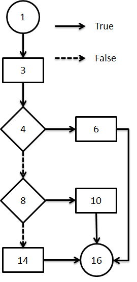

CFG Example

### 4.3.9 Test Adequacy Criteria

We can now return to the problem of selecting test cases so that our test suite is "good enough". In structural testing, to know whether a test suite is "good enough" we rely on **test suite adequacy criteria** defined using the CFG. A *test suite adequacy criterion* is a predicate that is true or false for a pair (program, test suite). For example, a development team could decide that for a test suite to be good enough for their program, "80% of all statements should be executed when the test suite is executed".

**Statement coverage** is the simplest criterion. It is defined as `(number of statements executed)/(number of statements in the program)`. In the example above, the test case `(3,4,1)` achieves `3/6 = 50%` statement coverage (here the start and end nodes are ignored). The rational for achieving statement coverage is simply that if a defect is present in a statement, it can't be detected if the statement is not executed. Full statement coverage corresponds to going through all the nodes in a CFG during the execution of a test suite. Note that line coverage and basic block coverage are alternatives that are practically equivalent to statement coverage.

**Branch coverage** is defined as `(number of branches executed)/(number of branches in the program)`. In the example above, the test case `(3,4,1)` achieves `1/4 = 25%` branch coverage. Full branch coverage corresponds to going through all the edges in a CFG during the execution of a test suite.

**Path coverage** is defined as `(number of paths executed)/(number of paths in the program)`. Path coverage corresponds to going through all the possible paths in a CFG during the execution of a test suite. In the example above, the test case `(3,4,1)` achieves `1/3 = 33%` path coverage. Path coverage is considered a *theoretical* criterion because although it can be a useful concept to reason about testing in general, it cannot be achieved in practice, in particular for code that contains loops.

Because many defects can lurk in conditional statements, a number of coverage criteria target condition coverage specifically. In the case of condition-related coverage, is is more common to refer to coverage in binary terms (full coverage is achieved vs. not), as opposed to a fraction of the possible coverage.

**Basic conditions coverage** is defined as "each basic condition must have a True and a False outcome at least once during the execution of the test suite". In the example above, the test case `(3,4,1)` does not achieve basic condition coverage because of the six possible condition-outcome pairs, only `true(q > 0)` on line 4 and `true(a!=0)` on line 4 are covered.

**Branch and conditions coverage** is defined as satisfying both the branch and basic conditions criteria. In the example above, the test case `(3,4,1)` does not achieve branch and condition coverage because it achieves neither the branch nor the basic condition criteria.

**Compound conditions** is defined as achieving each possible evaluation of compound conditions. In the general case the compound conditions criterion is also considered theoretical because of the the large number of resulting combinations.

Some of the coverage criteria have a **subsumption relation** between them. For criterion A to *subsume* criterion B means that if A is achieved, B is implicitly achieved. The following subsumption relations exist between the criteria seen in this module (the relation is [transitive](https://en.wikipedia.org/wiki/Transitive_relation)):

- Branch subsumes Statement
- Path subsumes Branch
- Branch and conditions subsumes both branch and basic conditions (by definition)
- Compound conditions subsumes branch and conditions

### 4.3.10 Practical Coverage Analysis

Test coverage is typically computed by tools that *instrument* the source or bytecode and report how much coverage is achieved for different criteria supported by the tool. For example, EclEmma supports instruction, line (a proxy for statement), and branch coverage. See the Module 0 exercises for instructions on how to install and run EclEmma.

### 4.3.11 Acknowledgements

The part of this module on test case selection and structural testing was adapted from a lecture originally created by Prof. Andreas Zeller based on material from the book "Software Testing and Analysis: Process, Principles, and Techniques", by Pezze & Young, Wiley, 2008

## 4.4 Reading

- The [Java Tutorial - Annotations](https://docs.oracle.com/javase/tutorial/java/annotations/index.html)
- The [Java Tutorial - Reflection](https://docs.oracle.com/javase/tutorial/reflect/)
- The [Vogella Unit Testing Tutorial](http://www.vogella.com/tutorials/JUnit/article.html)
- Solitaire v0.3 [TestGameModel](https://github.com/prmr/Solitaire/blob/v0.3/test/ca/mcgill/cs/stg/solitaire/model/TestGameModel.java) as a sample unit test demonstrating the use of reflection and simple mock objects.

## 4.5 Exercises

The best way to practice unit testing is, unsurprisingly, to write tests for as much code as possible. The exercises below provide some suggestions, but for additional practice you can write tests for practically any available code.

For maximum learning effectiveness, I recommend peeking at the answers only after giving the problems an honest try.

1. Write unit tests for the Java `Math.abs()` and `Math.min(...)`.
2. Write unit tests for the Java `Stack` methods `pop`, `push`, and `peek`.
3. Create CFGs for all the methods of class [RecentFilesQueue](https://github.com/prmr/JetUML/blob/v1.0/src/ca/mcgill/cs/stg/jetuml/framework/RecentFilesQueue.java), except for `serialize` and `deserialize`. With the help of EclEmma, write tests that achieve branch coverage. Manually compute the coverage for all three condition criteria.
4. :star: Extend the previous exercise to include the `serialize` and `deserialize` methods.
5. :spades: Write unit tests for all the classes of the Solitaire application you have developed so far. Compute the coverage of your test suite with EclEmma.
6. :star: Run EclEmma on JetUML and identify some untested code. Write a new unit test and submit it as a pull request.

## 4.6 Answers

Answers and answer sketches to the Module 4 practice exercises.

### 4.6.1 Exercise 1

See TestMath.java

# 5 Module 5 - Composition

## 5.1 Description

Large programs are typically assembled from smaller parts. In object-oriented programming this is done through two main mechanism: *composition* and *inheritance*. Composition simply means that one object holds a reference to another object and delegates some tasks to it. Although this sounds simple enough, unprincipled composition can lead to a terrible mess of spaghetti code. In this module I will give a quick refresher on the mechanism of polymorphism and how it can be used to elegantly compose objects together by following some well-known design patterns. Note that the second way of assembling systems is through inheritance, which is more complex and will be covered in Module 7.

## 5.2 Learning Objectives

After this module you should:

- Be able to explain the concept of object composition and its impact on object identity;
- Be able to use the Composite design pattern effectively;
- Be able to use the Decorator design pattern effectively;
- Be able to use the Command design pattern effectively;
- Be able to use the Prototype design pattern effectively;
- Understand the concept of polymorphic copying and be able to correctly use the Java cloning mechanism;
- To understand the Law of Demeter and be able to apply it;
- Generally solve design problems that involve manipulating object graphs;

## 5.3 Notes

### 5.3.1 General Concepts and Definitions

A general strategy for managing complexity in software design is to define larger abstractions in terms of smaller, ideally simpler ones. In practice one way to do this is **object composition**. Composing objects simply means that one object stores a reference to one or more other objects. Conceptually we could say composition can help achieve two purposes. One purpose is for one object to conceptually **aggregate** other objects and provides operations that are a function of these aggregated objects. An example is an instance of a class `Deck` that aggregates instances of class `Card`. In this case the methods of `Deck` basically are functions that operate on instances of `Card`, for example by shuffling them. Another way to understand composition is the idea of **delegation**, in that the container object *delegates* some services to the objects it contains. For example, in the Solitaire demonstration system, the `GameEngine` singleton object holds a reference to an instance of a `SuitStackManager` and *delegates* all the management of the state and computation of "suit stacks" to that object. The two purposes for composition are not mutually exclusive.

In a UML Class Diagram object composition is represented with an edge annotated with a diamond *on the side of the class whose instances hold the reference to the instances of the other class*. Note that the UML notation technically allows the distinction between two types of composition: "aggregation" (white diamond) and "composition" (black diamond). I don't use this distinction in this book, and exclusively use the "white diamond" annotation for all types of aggregation/compositions.

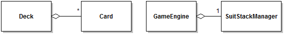

Although it's technically possible to combine objects in arbitrary ways simply by defining fields and passing object references around, unprincipled use of object composition quickly degenerates into overly-complex code. In this module I cover different ways to keep a certain amount of organization in the use of composition.

### 5.3.2 UML Sequence Diagrams

This module will discuss different ways to have groups of objects interact. The best way to model sequences of object interactions is through [UML Sequence Diagrams](http://www.ibm.com/developerworks/rational/library/3101.html). Just like object diagrams and state diagrams, Sequence Diagrams model the *dynamic* perspective on a software system. Like object diagrams and as opposed to state diagrams, Sequence Diagrams represent *a specific snapshot* in the execution of a program. They are the closest correspondence to what one would see in the debugger's execution stack as the code is executing.

I describe the notation of Sequence Diagram through an example. The scenario modeled is the use of an iterator in the Iterator design pattern seen in Module 2. The names of model elements are provided as notes on the diagram.

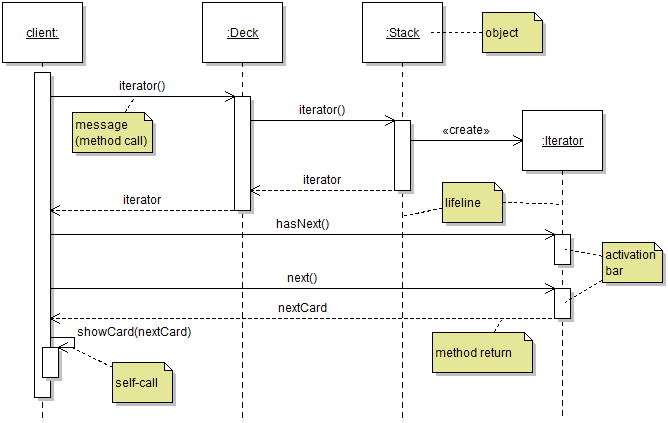

Each rectangle at the top of the diagram represents an **object**. Consistently with other UML diagrams representing system run-time, the objects names are underlined and follow the convention `name:type` as necessary. Note how I did *not* specify a type for the client because it does not matter, and did not specify a name for the `Deck` instance because it does not matter.

The dashed vertical line emanating from an object represents the object's **lifeline**. In systems terms it represents the time (running top-down) when the object exists, i.e., between its creation and the time it is garbage collected. When objects are placed at the top of the diagram, they are assumed to exist at the beginning of the scenario being modeled. It is also possible to show the creation of the instance by placing it lower in the diagram (e.g., the `Iterator` object). When representing the type of an object, there is some flexibility in terms of what type to represent in the object's type hierarchy (e.g., the concrete type of the object or one of its supertypes). As usual when modeling, we use what is the most informative. Here the `Deck` object is represented using its concrete type because that's really the only option, but for the `Iterator` object I used the interface supertype because in practice the concrete type of this object is anonymous and doesn't really matter.

**Messages** between objects typically correspond to method calls. Messages are represented using a directed arrow from the caller object to the called object. By "called object" we precisely mean "the object that is the implicit parameter of the method call". Messages are typically labeled with the method that is called, optionally with some symbol representing arguments, when useful. When creating a Sequence Diagram that represents an execution of a Java program, it's likely to be a modeling error if a message incoming on an object does *not* correspond to a method of the object's class. Constructor calls are modeled as special `create` messages.

Messages between objects induce an **activation box**, which is the thicker white box overlaid on the lifeline. The activation box represents the time when a method of the corresponding object is on the execution stack (but not necessarily at the top of the execution stack).

It is also possible to model the **return of control** out of a method back to the caller. This is represented with a dashed directed arrow. Return edges are optional. I personally only use them to aid understanding when there are complex sequences of messages, or to give a name to the value that is returned to make the rest of the diagram more self-explanatory. Here for example, I included a return edge from both `iterator()` calls to show (indirectly) that it's probably the same object being propagated back to the client. I also included a return edge from the `next()` method and labeled it `nextCard` to show that the returned object is the one being supplied to the subsequent **self-call** (a method called on an object from within a method already executing with this object as implicit parameter).

My usual reminder about the distinction between models and complete source code applies to sequence diagrams as well. First, a sequence diagram *models a specific execution, not all executions*. In the above example, a different execution could have received `false` from `hasNext()` and not called `next()`, or called `next()` twice, etc. These options are not represented, because they are different scenarios. Second, sequence diagrams will naturally *omit some details* of the execution of the code. We use sequence diagrams to show how objects interact to convey a specific idea. Although UML supports the specification of looping and conditional statements within a method, these are typically not included and I don't use this notation in the book. Insignificant calls (e.g., to library methods) are also typically omitted from sequence diagrams.

### 5.3.3 The Composite Design Pattern

It's not unusual when designing aggregations of objects to run into a situation where we would like to have groups of objects behave like single objects. This situation is best illustrated by the following design fragment for a hypothetical drawing editor.

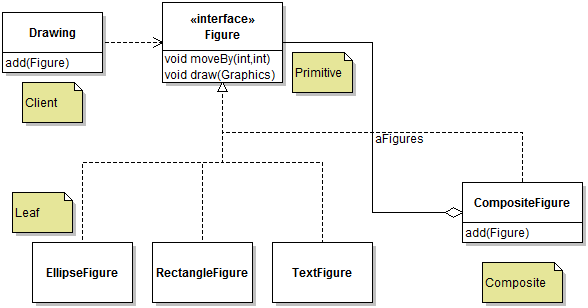

In this design, a `Drawing` instance aggregates a number of different `Figure` objects. A usual desirable feature of the problem domain (drawing figures) is that it should be possible to create figures by grouping different figures. This feature is realized in the design by the presence of class `CompositeFigure`. In the pattern this is referred to as the "Composite" role. Roles in the pattern are indicated using notes in the UML diagram. In this pattern the Composite class has two very important features:

1. It aggregates a number of different objects of type `Figure`. Using the primitive (interface) type is very important, as it allows the composite to compose any other kind of figures, including other composites.
2. It implements the primitive interface. This is basically what allows composite objects to be treated by the rest of the program in exactly the same way as "leaf" elements.

An example of the resulting structure is illustrated by the object diagram below.

[figure not shown]

When instantiating the Composite design pattern as part of a design, the implementation of the methods of the primitive's interface should most likely involve an iteration through all the composed elements. As a simple example, in the above design the implementation of method `CompositeFigure.draw(Graphics)` would most likely be:

```java
public void draw(Graphics pGraphics)
{
   for( Figure figure : aFigures )
   {
      figure.draw(pGraphics);
   }
}
```

A few other important implementation issues must be considered:

- Whether to have a single composite class for all different types of composite, or whether to have an abstract composite class that is subclassed by other more specific types of composites. Because inheritance is covered later in the course, we set this issue aside for now.
- The composite needs a way to add the instances of the primitive that it composes. This can be done using the constructor, or an `add` method. In the case of an `add` method, the question becomes whether to include the `add` method in the `Primitive` or not. The more common solution is to not include it in the primitive, but there may be some situations where it makes more sense to include it on the interface, for example to simplify code that makes heavy use of the `instanceof` operator.

Some practical aspects related to using the pattern are independent from the structure of the pattern itself. These include: * The location of the creation of the composite. * Any logic required to preserve the integrity of the object graph induced by this design (e.g., to prevent cycles, or non-sensical groups). Because these concerns are problem-dependent, their solution will depend on the specific design problem at hand.

### 5.3.4 The Decorator Design Pattern

In some cases we would like to optionally add some "features" to an object, but still be able to treat the object like any other object of the same type. Continuing with the example of the drawing editor, we might want to add a border to some figures, or maybe give some figures a transparency, or a non-photorealistic rendering, etc. Implementing features such as these *statically*, as attributes of the classes, has several drawbacks. First, not all objects will necessarily have a given feature, which means that the methods of the object would have to support a feature that may never be used. Second, and perhaps more importantly, the number of potential combination of features increases exponentially with the number of features, and so it goes with the general complexity of the code. For example, for the `Rectangle` class to be able to handle three features, the code of methods such as `draw` would have to account for 8 different possibilities. A better solution is to compose features *dynamically*. The **Decorator Design Pattern** captures the main underlying idea.

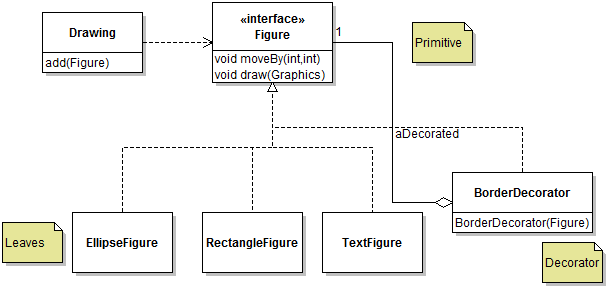

The Decorator design pattern looks very much like the Composite Design Pattern, except that instead of a Composite object we have a Decorator object. However, the constraints on the Decorator are very similar as those of the Composite:

1. It aggregates *one object* of type `Figure`. Using the primitive (interface) type is very important, as it allows the decorator to "decorate" any other kind of primitives, including other decorators (and composites!).
2. It implements the primitive interface. This is basically what allows decorator objects to be treated by the rest of the program in exactly the same way as "leaf" elements.

The main question to resolve when implementing the Decorator is what the methods of the Decorator class should do. In a classic use of the Decorator design pattern, the implementation of the interface's methods should basically involve two steps, illustrated with the code for the `draw` method:

```java
public void draw(Graphics pGraphics)
{
   // 1. Delegate the original request to the decorated object
   aDecorated.draw(pGraphics);

   // 2. Implement the decoration
   // Draw the border using the Graphics object
}
```

There is no prescribed order for these two steps, although in some case the problem domain may impose an order. The following sequence diagram illustrates the delegation sequence when using a Decorator (note that the order is reversed from that of the code example):

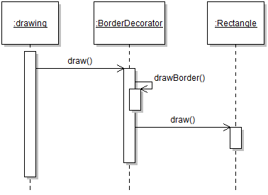

When implementing the Decorator design pattern in Java, it's a good idea to specify as `final` the field that stores a reference to the decorated object, and to initialize it in the constructor. A common expectation when using the Decorator Design Pattern is that a decorator object will decorate the same object throughout its life-time.

Finally, Decorator and Composite classes can easily co-exist in a class hierarchy. The object diagram below illustrates an object graph induced by a combination of composite and decorator objects.

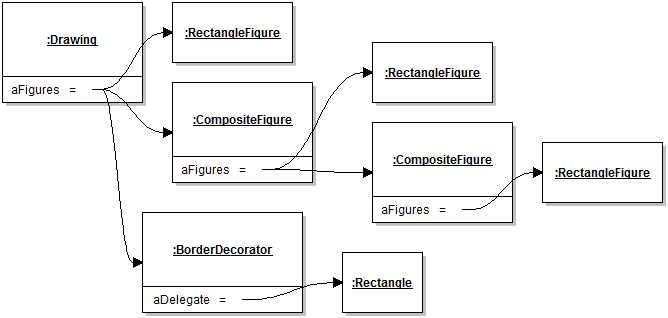

### 5.3.5 Polymorphic Object Copying

In Module 1 I discussed situations where it's useful to copy some objects, and introduced the idea of copy constructors, which allow a client to make a copy of an object passed as argument:

```java
Card cardCopy = new Card(pCard);
```

Copy constructors work fine in many situations, but their main limitation is that to call a constructor it is necessary to make a static reference to a specific class (here, class `Card`). In designs that make use of polymorphism, this is a problem. Consider the scenario of a drawing editor illustrated above. Assume that in the `Drawing` class we collect reference to a number of `Figure` instances.

```java
public class Drawing
{
   private List<Figure> aFigures = ...;
   ...
}
```

In this design, an instance of `Drawing` would collect references to `Figure` instances of different concrete types (e.g., `RectangleFigure`, `TextFigure`, etc.). Say we want to make copies of all the figures in `aFigures`. How to proceed, since we don't know the exact type of each figure object? (We could use metaprogramming to discover it, but that's messy).

The solution to this problem is to use a mechanism that provides us with *polymorphic object copying*. In other words, we want to be able to make copies of objects without knowing the exact concrete type of the object. In Java this feature is supported by a mechanism called **cloning**.

Cloning is one of Java's most convoluted and counter-intuitive mechanisms. There are many tutorials available on Java cloning (e.g., [this one](http://howtodoinjava.com/core-java/cloning/a-guide-to-object-cloning-in-java/)). Here I only discuss the main recipe for achieving cloning, and report some of the more in-depth discussion of the rationale some of the mechanism's design decisions to Module 7 because the explanations require knowledge of inheritance.

To make it possible to clone a class, the first step is to **tag the class as cloneable** using the `Cloneable` tagging interface:

```java
public class Card implements Cloneable {
```

This allows other objects to check whether an object can be cloned, e.g.:

```java
if( o instanceof Cloneable ) { clone = o.clone(); }
```

The second step is to **override the `clone` method**. The method `Object clone()` is defined in class `Object`, but its access modifier is `protected`, so methods that don't have access to the cloneable class's target method can't see it. When overriding `clone`, it is therefore necessary to *widen its visibility* to `public`.

```java
@Override
public Card clone()
{
```

Note that since Java 5 it is possible to change the return type from the original `Object` to the more specific `Card` (this feature is called a *covariant return type*).

The overridden clone method needs to create a new object of the same class. For reason that will become clearer in Module 7, this **should only be done by calling `super.clone()`**, not by calling a constructor.

```java
@Override
public Card clone()
{
   Card clone = super.clone();
   // NOT Card clone = new Card();
```

The statement `super.clone` calls the `clone` method in the superclass, which here means method `Object.clone`. This method is very special. It uses metaprogramming features to return *an object of the class from where the call to the method originates*. This is special because although the method is implemented in the library class `Object`, it still returns a new instance of class `Card`. Method `Object.clone` is special because it also does not create a "fresh" instance of the class by internally calling the default constructor (sometimes there isn't even a default constructor). Instead, it reflectively creates a new instance of the class initialized by making a shallow copy of all the instances fields. Whenever a shallow copy is not sufficient, the overridden `clone` method must perform additional steps to more deeply copy some of the fields.

For example, a reasonable implementation of `clone` of a class `Deck` would look like this:

```java
public Deck clone()
{
   try
   {
      Deck lReturn = (Deck)super.clone();
      lReturn.aCards = new Stack<>();
      for( Card card : aCards )
      {
         lReturn.aCards.add(card);
      }
      return lReturn;
   }
   catch (CloneNotSupportedException e)
   {
      return null;
   }
```

As you notice, the call to `super.clone` declares to throw a `CloneNotSupportedException` that must be caught. This exception is only raised if `super.clone` is called from within a class that is *not* declared to implement `Cloneable`. If we properly declared our class (`Card` or `Deck`) to be `Cloneable`, then we can be assured that this exception will never be raised, and we can safely squash it by catching it and doing nothing. The reason for this awkward exception-handling requirement is that because the default cloning behavior implemented by `Object.clone` (shallow copying) is potentially not appropriate for a class (like `Deck`), a programmer should not be able to call `clone` "accidentally". Having to catch the exception is supposed to force programmers to remember this, although it's not clear to what extent this trick was successful.

The last, optional, step when using cloning is to add the `clone` method to the super type of a hierarchy of classes whose objects we want to clone. In the `DrawingEditor` example, we would probably want to add `clone` to the `Figure` interface. Unfortunately, the `Cloneable` interface does not include the `clone` method, so that the `clone` method will not automatically be visible to clients of `Cloneable` types. Another useful trick is to make the hierarchy supertype extend clone instead of making all the concrete type declare to implement it individually, e.g.;

```java
public interface Figure extend Cloneable
...
```